```r
library(lubridate)
```

```r
library(taRifx)
library(ggplot2)
library(purrr)
```

## Data set building

```r
# Path of the directory for each year for men
years_men_path <- list.dirs(path = '../biathlon_analysis/biathlon_data/men',
                            recursive=FALSE,full.names=TRUE)

# Path of the directory for each year for women
years_women_path <- list.dirs(path='../biathlon_analysis/biathlon_data/women',
                              recursive=FALSE,full.names=TRUE)

# List of years directory names for men
years_men <- list.dirs(path = '../biathlon_analysis/biathlon_data/men',
                       recursive = FALSE, full.names=FALSE)

# List of years directory names for women
years_women <- list.dirs(path = '../biathlon_analysis/biathlon_data/women',
                         recursive =FALSE,full.names=FALSE)

# Initializing the list of years present in the data set
years <- c(1:length(years_men))

# Filling the list of years present in the data set
for (i in c(1:length(years_men))){

  idx <- unlist(gregexpr('_', years_men[[i]]))
  string <- unlist(strsplit((years_men[[i]]),""))
  final_year <- paste(string[1:idx-1], collapse="")
  years[i] <- final_year
}
```

```r
# Initializing the named list of word cup locations
locations <- list()

# Filling the list having as names the year and as values the locations of the word cup venues
for (i in seq_along(years)){

locations[[years[i]]] <- (list.dirs(path = years_men_path[i], recursive = FALSE, full.names = FALSE))
}
# Initializing a list that has to be similar to the previous one but with the full path as values
locations_path_men <- list()

# Same thing for women
locations_path_women <- list()

# Filling the list
for (i in seq_along(years)){

  locations_path_men[[years[i]]] <- (list.dirs(path = years_men_path[i], recursive = FALSE, full.names = TRUE))
}


for (i in seq_along(years)){

  locations_path_women[[years[i]]] <- (list.dirs(path = years_women_path[i], recursive = FALSE, full.names = TRUE))
}
```

```r
# Defining a custom infix operator to take the role of the not %in% operator
'%!in%' <- function(a,b) {!( '%in%'(a,b))}
```

```r
# Initializing the final data frame of the result of each race
df_results_men <- data.frame()

# Initializing the id of the race
race_id <- 0

# Initializing the count of all the DNS
res_dns_men <- 0

# Initializing the count of all the DSQ
res_dsq_men <- 0

# Initializing the count of all the DNF
res_dnf_men <- 0

# Initializing the count of all the lapped athletes
res_lap_men <- 0

# Initializing the count of all the bibs > 120 because they won't appear in loops,
# this happens only in Kontiolahti 2014, these damned Finnish...
res_over_men <- 0

# The allowable values for the Rank column of the data frame
allowables <- c(c(1:127), 'DNF', 'DNS', 'DSQ', 'LAP')

# Initializing the list connecting each race to the race_id
list_id_men <- list()


for (i in seq_along(years)){
  for(j in seq_along(locations[[years[i]]])){
    files <- list.files(locations_path_men[[years[i]]],
                  pattern=sprintf('results.%s',locations[[years[i]]][j]),full.names = TRUE )
    # Importing the data frame
    for (file in files){


      race_id <- race_id + 1


      df_res <- read.csv(file = file, sep = '\t')

      # Raising a flag if the Rank column has not allowable columns
      if(length(df_res$Rank[df_res$Rank %!in% allowables]) !=0){cat('wooow problem, in', file)}

      # Updating the count of bibs > 120
      res_over_men <- res_over_men + length(df_res$Rank[destring(df_res$Rank) > 120]
             [! is.na(df_res$Rank[destring(df_res$Rank) > 120])])

      # Updating the DNS count
      res_dns_men <- res_dns_men + length(df_res$Rank[df_res$Rank=='DNS'])

      # Updating the DNF count
      res_dnf_men <- res_dnf_men + length(df_res$Rank[df_res$Rank=='DNF'])

      # Updating the DSQ count
      res_dsq_men <- res_dsq_men + length(df_res$Rank[df_res$Rank=='DSQ'])

      # Updating the lapped athletes' count
      res_lap_men <- res_lap_men + length(df_res$Rank[df_res$Rank=='LAP'])


      # Checking for possible inconsistencies in the data set
      if('Rank' %!in% colnames(df_res)){
        cat(paste('There is a mistake in', file))
      }
      # Adding the isolated.pursuit column to the non-pursuit races in order to have the same
      # columns to perform the rbind operation
      else if('Isolated.Pursuit' %!in% colnames(df_res)){
        df_res$Isolated.Pursuit <- rep(NA, nrow(df_res))
      }

      # Adding the column specifying the year of the race
      df_res$year <- rep(years[i], nrow(df_res))
      # Adding the column specifying the venue of the race
      df_res$location <- rep(locations[[years[i]]][j], nrow(df_res))
      # Adding the column with the id of the race
      df_res$ID <- rep(race_id, nrow(df_res))

      # Adding the column specifying the type of the race
      if (grepl(pattern = 'pursuit', x =file, fixed=TRUE)){
        df_res$race_type <- rep('Pursuit', nrow(df_res))
      }
      else if (grepl(pattern = 'individual', x =file, fixed=TRUE)){
        df_res$race_type <- rep('Individual', nrow(df_res))
      }
      else if (grepl(pattern = 'mass_start', x =file, fixed=TRUE)){
        df_res$race_type <- rep('Mass start', nrow(df_res))
      }
      else if (grepl(pattern = 'sprint', x =file, fixed=TRUE)){
        df_res$race_type <- rep('Sprint', nrow(df_res))
      }
      else{
        cat(paste('There is a mistake in',file,
                  'no race type specified'))
      }

      # Filling the list connecting the id to the race, the unique identifier for a race has
      # been chosen as a touple, we need also the name of the runner-up because Samuelsson won back
      # to back spring in Oestersund in 2021... Sebastian, I know you are training with Luki right now
      #but you also # could have avoided being so awesome
      list_id_men[[paste(df_res$race_type[1], years[i], locations[[years[i]]][j],
                         df_res$Given.Name[1], df_res$Given.Name[2])]] <- race_id

      # Updating the final data frame
      df_results_men <- rbind(df_results_men, df_res)
    }
  }
}
```

```r
# Initializing the final data frame of the result of each race
df_results_women <- data.frame()

# Initializing the id of the race
race_id <- 0

# Initializing the count of all the DNS
res_dns_women <- 0

# Initializing the count of all the DSQ
res_dsq_women <- 0

# Initializing the count of all the DNF
res_dnf_women <- 0

# Initializing the count of all the lapped athletes
res_lap_women <- 0

# Initializing the count of all the bibs > 120 because they won't appear in loops,
# this happens only in Kontiolahti 2014, these damned Finnish...
res_over_women <- 0

# The allowable values for the Rank column of the data frame
allowables <- c(c(1:127), 'DNF', 'DNS', 'DSQ', 'LAP')

# Defining the list connectiong races to their id
list_id_women <- list()

for (i in seq_along(years)){
  for(j in seq_along(locations[[years[i]]])){
    files <- list.files(locations_path_women[[years[i]]],
                  pattern=sprintf('results.%s',locations[[years[i]]][j]),full.names = TRUE )
    # Importing the data frame
    for (file in files){

      # Updating the race_id that will act as our primary key of the data set
      race_id <- race_id + 1

      list_id_women[[file]] <- race_id

      df_res <- read.csv(file = file, sep = '\t')

      # Raising a flag if the Rank column has not allowable columns
      if(length(df_res$Rank[df_res$Rank %!in% allowables]) !=0){cat('wooow problem, in', file)}

      # Updating the count of bibs > 120
      res_over_women <- res_over_women + length(df_res$Rank[destring(df_res$Rank) > 120]
             [! is.na(df_res$Rank[destring(df_res$Rank) > 120])])

      # Updating the DNS count
      res_dns_women <- res_dns_women + length(df_res$Rank[df_res$Rank=='DNS'])

      # Updating the DNF count
      res_dnf_women <- res_dnf_women + length(df_res$Rank[df_res$Rank=='DNF'])

      # Updating the DSQ count
      res_dsq_women <- res_dsq_women + length(df_res$Rank[df_res$Rank=='DSQ'])

      # Updating the lapped athletes' count
      res_lap_women <- res_lap_women + length(df_res$Rank[df_res$Rank=='LAP'])


      # Checking for possible inconsistencies in the data set
      if('Rank' %!in% colnames(df_res)){
        cat(paste('There is a mistake in', file))
      }
      # Adding the isolated.pursuit column to the non-pursuit races in order to have the same
      # columns to perform the rbind operation
      else if('Isolated.Pursuit' %!in% colnames(df_res)){
        df_res$Isolated.Pursuit <- rep(NA, nrow(df_res))
      }

      # Adding the column specifying the year of the race
      df_res$year <- rep(years[i], nrow(df_res))
      # Adding the column specifying the venue of the race
      df_res$location <- rep(locations[[years[i]]][j], nrow(df_res))
      # Adding the column with the id of the race
      df_res$ID <- rep(race_id, nrow(df_res))

      # Adding the column specifying the type of the race
      if (grepl(pattern = 'pursuit', x =file, fixed=TRUE)){
        df_res$race_type <- rep('Pursuit', nrow(df_res))
      }
      else if (grepl(pattern = 'individual', x =file, fixed=TRUE)){
        df_res$race_type <- rep('Individual', nrow(df_res))
      }
      else if (grepl(pattern = 'mass_start', x =file, fixed=TRUE)){
        df_res$race_type <- rep('Mass start', nrow(df_res))
      }
      else if (grepl(pattern = 'sprint', x =file, fixed=TRUE)){
        df_res$race_type <- rep('Sprint', nrow(df_res))
      }
      else{
        cat(paste('There is a mistake in',file,
                  'no race type specified'))
      }

      # Filling the list as we did for the men, popping out the disqualified is due to the
      # Glaryzina affair
      list_id_women[[paste(df_res$race_type[1], years[i], locations[[years[i]]][j],
                         df_res$Given.Name[df_res$Rank %!in% c('DSQ')][1],
                         df_res$Given.Name[df_res$Rank %!in% c('DSQ')][2])]] <- race_id

      # Updating the final data frame
      df_results_women <- rbind(df_results_women, df_res)
    }
  }
}
```

```r
head(df_results_women)
```

```
##   Rank Bib  Family.Name Given.Name Nation Total Shootings Total.Time  Behind
## 1    1   1   Domracheva      Darya    BLR     1   1+0+0+0    30:58.5
## 2    2  11   Virolainen      Daria    RUS     1   0+0+0+1    32:19.5 +1:21.0
## 3    3   2   Makarainen      Kaisa    FIN     5   2+0+1+2    32:27.5 +1:29.0
## 4    4   6   Hildebrand  Franziska    GER     1   0+0+1+0    32:27.8 +1:29.3
## 5    5  19 Dorin Habert      Marie    FRA     2   0+1+1+0    32:36.5 +1:38.0
## 6    6   8      Dunklee      Susan    USA     1   0+1+0+0    32:39.3 +1:40.8
##   Isolated.Pursuit      year   location ID race_type
## 1          30:58.5 2014-2015 Anterselva  1   Pursuit
## 2          31:05.5 2014-2015 Anterselva  1   Pursuit
## 3          32:00.5 2014-2015 Anterselva  1   Pursuit
## 4          31:26.8 2014-2015 Anterselva  1   Pursuit
## 5          31:10.5 2014-2015 Anterselva  1   Pursuit
## 6          31:29.3 2014-2015 Anterselva  1   Pursuit
```

```r
head(df_results_men)
```

```
##   Rank Bib Family.Name Given.Name Nation Total Shootings Total.Time Behind
## 1    1   1     Schempp      Simon    GER     2   1+1+0+0    31:27.9
## 2    2   8        Eder      Simon    AUT     1   0+1+0+0    31:28.0   +0.1
## 3    3   2  Garanichev    Evgeniy    RUS     1   0+0+1+0    31:29.0   +1.1
## 4    4   9 Bjoerndalen  Ole Einar    NOR     0   0+0+0+0    31:29.8   +1.9
## 5    5  25    Fourcade     Martin    FRA     0   0+0+0+0    31:59.8  +31.9
## 6    6  19      Lesser       Erik    GER     0   0+0+0+0    32:13.5  +45.6
##   Isolated.Pursuit      year   location ID race_type
## 1          31:27.9 2014-2015 Anterselva  1   Pursuit
## 2          30:52.0 2014-2015 Anterselva  1   Pursuit
## 3          31:15.0 2014-2015 Anterselva  1   Pursuit
## 4          30:46.8 2014-2015 Anterselva  1   Pursuit
## 5          30:39.8 2014-2015 Anterselva  1   Pursuit
## 6          31:05.5 2014-2015 Anterselva  1   Pursuit
```

```r
# Initializing the race_id for the second to last loop data frame
race_id <- 0
# The set of allowable values for the Rank column of the loop data frame
allowables <- c(1:127)
# Initializing the final loop data frame
df_final_loop_men <- data.frame()

# Beginning the cycle that loops over every year and every venue
for (i in seq_along(years)){

  for(j in seq_along(locations[[years[i]]])){


    # All the files that represent a loop in our directory
    files <- list.files(locations_path_men[[years[i]]],
                  pattern=sprintf('loop...%s',locations[[years[i]]][j]),full.names = TRUE )

      # Looping over all the files
      for (file in files){
        # Here we select, between all loop files the ones that represent the second to last loop,
        # that is, the loop in which the biathlete arrive at the last shooting range
        if (
            (grepl(pattern = 'pursuit', x =file, fixed=TRUE)
            &&
            grepl(pattern = 'loop_4', x =file, fixed=TRUE))
            ||
            (grepl(pattern = 'sprint', x =file, fixed=TRUE)
             &&
            grepl(pattern = 'loop_2', x =file, fixed=TRUE))
            ||
            (grepl(pattern = 'individual', x =file, fixed=TRUE)
             &&
            grepl(pattern = 'loop_4', x =file, fixed=TRUE))
            ||
            (grepl(pattern = 'mass_start', x =file, fixed=TRUE)
             &&
            grepl(pattern = 'loop_4', x =file, fixed=TRUE))

            ){
            # Updating the race id


            # Reading the file into a data frame
            df_loop <- read.csv2(file = file, sep = '\t')

            # Here we raise a flag if we don't have the Rank colun in the created data frame
            if('Rank' %!in% colnames(df_loop)){
                cat(paste('There is a mistake in', file, '\n'))

            # Here we raise a flag and print the relative fail if we have a Rank value that is not allowed
            if(length(df_loop$Rank[df_loop$Rank %!in% allowables]) !=0){cat('wooow problem, in', file)}


            }

            # The column Ski.Time is present only on individual races, for tha others we fill it with 0
            # in order to make the rbind possible
            if ('Ski.Time'%!in% colnames(df_loop)){
              df_loop[['Ski.Time']] <- rep(0, nrow(df_loop))
            }

            # The Canmore's short individual did not have the Range.Time column, so we create it for the
            # rbind... but who cares about short individuals anyway!!!
            if ('Range.Time'%!in% colnames(df_loop)){
              df_loop[['Range.Time']] <- rep(0, nrow(df_loop))
            }

            # The columns of the data frame
            columns_df <- colnames(df_loop)

            # The index from which column regarding times start
            idx_time_columns <- which(columns_df=='Nation')

            # The 'time' columns of the table, the -1 at the end is to delete 'Nation'
            # that is not between them
            time_columns <- columns_df[idx_time_columns:length(columns_df)][-1]

            # Adding the column specifying the year of the race
            df_loop$year <- rep(years[i], nrow(df_loop))

            # Adding the column specifying the venue of the race
            df_loop$location <- rep(locations[[years[i]]][j], nrow(df_loop))



            # Adding the column specifying the type of the race
            if (grepl(pattern = 'pursuit', x =file, fixed=TRUE)){
              df_loop$race_type <- rep('Pursuit', nrow(df_loop))
            }
            else if (grepl(pattern = 'individual', x =file, fixed=TRUE)){
              df_loop$race_type <- rep('Individual', nrow(df_loop))
            }
            else if (grepl(pattern = 'mass_start', x =file, fixed=TRUE)){
              df_loop$race_type <- rep('Mass start', nrow(df_loop))
            }
            else if (grepl(pattern = 'sprint', x =file, fixed=TRUE)){
              df_loop$race_type <- rep('Sprint', nrow(df_loop))
            }
            else{
              cat(paste('There is a mistake in',file,
                        'no race type specified'))
            }

            # Assigning to the race the same id that it has on the results data frame
            df_loop$ID <-rep( list_id_men[[paste(df_loop$race_type[1], years[i], locations[[years[i]]][j],
                         df_loop$Given.Name[1],  df_loop$Given.Name[2])]], nrow(df_loop))

            # Initializing the list of the reference times among all the columns, we have in fact that
            # time columns are note stored as absolute times: we have a reference time and then the other records
            # reference to it as +'time_interval'
            reference_times <- list()

            # Looping over all the time columns
            for(column in time_columns){

              # In individual races penalty times, as we know, are a thing of their own and the data set
              # itself seem to have noticed! It does not have in fact a value for biathletes that found the
              # 0 in a certain shooting range. We deal with it by giving by default the value 0.
              # We know what you are thinking: What if every one missed at least once?
              # Come on have a little trust in your sport heroes! as soon as Sturla Holm Lægreid will be around
              # we are more them safe!
              if (column == 'Penalty.Time'
                  &&
                  grepl(pattern = 'individual', x = file, fixed=TRUE)
                  )
              {reference_time <- duration(second = 0)}

              # In the else statement instead we select as the reference time the record with no '+' in
              # its body, the [1] is there to arbitrary break the ties between equally good reference times
              else{
                reference_time <- df_loop[[column]][!grepl(pattern = '+', x =df_loop[[column]],
                            fixed=TRUE)]
                }
              reference_time <- reference_time[1]

              # In this if cycle we convert the reference time from a string to a time duration
              # thanks to the lubridate package and its duration function

              # The first case is for whe we have minutes and not only second where we have a column
              # as a separator
              if (grepl(pattern = ':', x  = reference_time,
                            fixed=TRUE)){

                # Changing the reference time into an iterable
                string_sep <- unlist(strsplit((reference_time),""))

                # Getting the index of the column
                idx_sep <- unlist(gregexpr(':', reference_time, fixed = TRUE))

                # This step raises a flag if having a double colon signaling hours,
                # comes out: biathletes are no snails!
                if (length(idx_sep) > 1){cat(paste('Do we have hours now?? in', file  ))}

                # The minute part of the reference time
                min <- as.numeric(paste(string_sep[1:idx_sep-1], collapse=""))

                # The second part of the reference time
                sec <- as.numeric(paste(string_sep[-c(1:idx_sep)], collapse=""))
                reference_time_ <- duration(minute= min, second=sec)

              }
              # This second case is for reference times that don't reach a minute
              else{
                sec <- as.numeric(reference_time)
                reference_time_ <- duration(second=sec)
              }

              # Updating the list
              reference_times[[column]] <- reference_time_

              # Index of the reference times
              reference_time_idx <- which(!grepl(pattern = '+', x =df_loop[[column]],
                            fixed=TRUE))

              # Renaming the times of the current columns
              times_to_add <- df_loop[[column]]

              # Initializing the column of the absolute times
              final_adding <- c()

              # Filling the final_adding vector
              for (k in seq_along(times_to_add)){

                # Putting in the reference times
                if (k %in% reference_time_idx){
                  final_adding[k] <- reference_times[[column]]
                }

                # Putting in the 'minutes' recorda
                else if (grepl(pattern = ':', x =times_to_add[k], fixed=TRUE)){
                  string_add <- unlist(strsplit((times_to_add[k]),""))
                  idx_add <- unlist(gregexpr(':', times_to_add[k]))

                  # Flag raise for 'hour' times
                  if (length(idx_add) > 1){print('Do we have hours now?? in', file)}

                  min_add <- as.numeric(paste(string_add[1:idx_add-1], collapse=""))
                  sec_add <- as.numeric(paste(string_add[-c(1:idx_add)], collapse=""))

                  adding_time <- duration(minute= min_add, second=sec_add)

                  # Here the [1] is present for arbitrarily breaking ties for equally good
                  # reference times
                  final_adding[k] <- adding_time + reference_times[[column]][1]
                }
                else{

                  # The original data frame contained a couple of 'broken' records, being only
                  # the string '+', we changed the values to a known fixed outlier ('+1000') and here
                  # we transform it into NA
                  if (times_to_add[k]=='+1000') {final_adding[k] <- NA}

                  # Non pathological case were we have a 'seconds' time
                  else{
                    final_adding[k] <- duration(second = as.numeric(times_to_add[k])) +
                      reference_times[[column]]
                  }
                }

              }

              # Updating the column of the data frame
              df_loop[[column]] <- final_adding


            }

          # Binding together the data frames
          df_final_loop_men <- rbind(df_final_loop_men, df_loop)

      }
    }
  }
}
```

```r
df_final_loop_men
```

[output not shown]

[output cut: 18736 more lines]

```r
# Initializing the race_id for the second to last loop data frame
race_id <- 0
# The set of allowable values for the Rank column of the loop data frame
allowables <- c(1:127)
# Initializing the final loop data frame
df_final_loop_women <- data.frame()

# Beginning the cycle that loops over every year and every venue
for (i in seq_along(years)){

  for(j in seq_along(locations[[years[i]]])){


    # All the files that represent a loop in our directory
    files <- list.files(locations_path_women[[years[i]]],
                  pattern=sprintf('loop...%s',locations[[years[i]]][j]),full.names = TRUE )

      # Looping over all the files
      for (file in files){
        # Here we select, between all loop files the ones that represent the second to last loop,
        # that is, the loop in which the biathlete arrive at the last shooting range
        if (
            (grepl(pattern = 'pursuit', x =file, fixed=TRUE)
            &&
            grepl(pattern = 'loop_4', x =file, fixed=TRUE))
            ||
            (grepl(pattern = 'sprint', x =file, fixed=TRUE)
             &&
            grepl(pattern = 'loop_2', x =file, fixed=TRUE))
            ||
            (grepl(pattern = 'individual', x =file, fixed=TRUE)
             &&
            grepl(pattern = 'loop_4', x =file, fixed=TRUE))
            ||
            (grepl(pattern = 'mass_start', x =file, fixed=TRUE)
             &&
            grepl(pattern = 'loop_4', x =file, fixed=TRUE))

            ){
            # Updating the race id
            race_id <- race_id + 1

            # Reading the file into a data frame
            df_loop <- read.csv2(file = file, sep = '\t')

            # Here we raise a flag if we don't have the Rank colun in the created data frame
            if('Rank' %!in% colnames(df_loop)){
                cat(paste('There is a mistake in', file, '\n'))

            # Here we raise a flag and print the relative fail if we have a Rank value that is not allowed
            if(length(df_loop$Rank[df_loop$Rank %!in% allowables]) !=0){cat('wooow problem, in', file)}


            }

            # The column Ski.Time is present only on individual races, for tha others we fill it with 0
            # in order to make the rbind possible
            if ('Ski.Time'%!in% colnames(df_loop)){
              df_loop[['Ski.Time']] <- rep(0, nrow(df_loop))
            }

            # The Canmore's short individual did not have the Range.Time column, so we create it for the
            # rbind... but who cares about short individuals anyway!!!
            if ('Range.Time'%!in% colnames(df_loop)){
              df_loop[['Range.Time']] <- rep(0, nrow(df_loop))
            }

            # The columns of the data frame
            columns_df <- colnames(df_loop)

            # The index from which column regarding times start
            idx_time_columns <- which(columns_df=='Nation')

            # The 'time' columns of the table, the -1 at the end is to delete 'Nation'
            # that is not between them
            time_columns <- columns_df[idx_time_columns:length(columns_df)][-1]

            # Adding the column specifying the year of the race
            df_loop$year <- rep(years[i], nrow(df_loop))

            # Adding the column specifying the venue of the race
            df_loop$location <- rep(locations[[years[i]]][j], nrow(df_loop))



            # Adding the column specifying the type of the race
            if (grepl(pattern = 'pursuit', x =file, fixed=TRUE)){
              df_loop$race_type <- rep('Pursuit', nrow(df_loop))
            }
            else if (grepl(pattern = 'individual', x =file, fixed=TRUE)){
              df_loop$race_type <- rep('Individual', nrow(df_loop))
            }
            else if (grepl(pattern = 'mass_start', x =file, fixed=TRUE)){
              df_loop$race_type <- rep('Mass start', nrow(df_loop))
            }
            else if (grepl(pattern = 'sprint', x =file, fixed=TRUE)){
              df_loop$race_type <- rep('Sprint', nrow(df_loop))
            }
            else{
              cat(paste('There is a mistake in',file,
                        'no race type specified'))
            }

             # Adding the column with the id of the race

            # Assigning to the race the same id that it has on the results data frame
            df_loop$ID <-rep( list_id_women[[paste(df_loop$race_type[1], years[i], locations[[years[i]]][j],
                         df_loop$Given.Name[df_res$Rank %!in% c('DSQ')][1],
                         df_loop$Given.Name[df_res$Rank %!in% c('DSQ')][2])]], nrow(df_loop))

            # Initializing the list of the reference times among all the columns, we have in fact that
            # time columns are note stored as absolute times: we have a reference time and then the other records
            # reference to it as +'time_interval'
            reference_times <- list()

            # Looping over all the time columns
            for(column in time_columns){

              # In individual races penalty times, as we know, are a thing of their own and the data set
              # itself seem to have noticed! It does not have in fact a value for biathletes that found the
              # 0 in a certain shooting range. We deal with it by giving by default the value 0.
              # We know what you are thinking: What if every one missed at least once?
              # Come on have a little trust in your sport heroes! as soon as Sturla Holm Lægreid will be around
              # we are more them safe!
              if (column == 'Penalty.Time'
                  &&
                  grepl(pattern = 'individual', x = file, fixed=TRUE)
                  )
              {reference_time <- duration(second = 0)}

              # In the else statement instead we select as the reference time the record with no '+' in
              # its body, the [1] is there to arbitrary break the ties between equally good reference times
              else{
                reference_time <- df_loop[[column]][!grepl(pattern = '+', x =df_loop[[column]],
                            fixed=TRUE)]
                }
              reference_time <- reference_time[1]

              # In this if cycle we convert the reference time from a string to a time duration
              # thanks to the lubridate package and its duration function

              # The first case is for whe we have minutes and not only second where we have a column
              # as a separator
              if (grepl(pattern = ':', x  = reference_time,
                            fixed=TRUE)){

                # Changing the reference time into an iterable
                string_sep <- unlist(strsplit((reference_time),""))

                # Getting the index of the column
                idx_sep <- unlist(gregexpr(':', reference_time, fixed = TRUE))

                # This step raises a flag if having a double colon signaling hours,
                # comes out: biathletes are no snails!
                if (length(idx_sep) > 1){cat(paste('Do we have hours now?? in', file  ))}

                # The minute part of the reference time
                min <- as.numeric(paste(string_sep[1:idx_sep-1], collapse=""))

                # The second part of the reference time
                sec <- as.numeric(paste(string_sep[-c(1:idx_sep)], collapse=""))
                reference_time_ <- duration(minute= min, second=sec)

              }
              # This second case is for reference times that don't reach a minute
              else{
                sec <- as.numeric(reference_time)
                reference_time_ <- duration(second=sec)
              }

              # Updating the list
              reference_times[[column]] <- reference_time_

              # Index of the reference times
              reference_time_idx <- which(!grepl(pattern = '+', x =df_loop[[column]],
                            fixed=TRUE))

              # Renaming the times of the current columns
              times_to_add <- df_loop[[column]]

              # Initializing the column of the absolute times
              final_adding <- c()

              # Filling the final_adding vector
              for (k in seq_along(times_to_add)){

                # Putting in the reference times
                if (k %in% reference_time_idx){
                  final_adding[k] <- reference_times[[column]]
                }

                # Putting in the 'minutes' recorda
                else if (grepl(pattern = ':', x =times_to_add[k], fixed=TRUE)){
                  string_add <- unlist(strsplit((times_to_add[k]),""))
                  idx_add <- unlist(gregexpr(':', times_to_add[k]))

                  # Flag raise for 'hour' times
                  if (length(idx_add) > 1){print('Do we have hours now?? in', file)}

                  min_add <- as.numeric(paste(string_add[1:idx_add-1], collapse=""))
                  sec_add <- as.numeric(paste(string_add[-c(1:idx_add)], collapse=""))

                  adding_time <- duration(minute= min_add, second=sec_add)

                  # Here the [1] is present for arbitrarily breaking ties for equally good
                  # reference times
                  final_adding[k] <- adding_time + reference_times[[column]][1]
                }
                else{

                  # The original data frame contained a couple of 'broken' records, being only
                  # the string '+', we changed the values to a known fixed outlier ('+1000') and here
                  # we transform it into NA
                  if (times_to_add[k]=='+1000') {final_adding[k] <- NA}

                  # Non pathological case were we have a 'seconds' time
                  else{
                    final_adding[k] <- duration(second = as.numeric(times_to_add[k])) +
                      reference_times[[column]]
                  }
                }

              }

              # Updating the column of the data frame
              df_loop[[column]] <- final_adding


            }

          # Binding together the data frames
          df_final_loop_women <- rbind(df_final_loop_women, df_loop)

      }
    }
  }
}
```

```r
head(df_final_loop_women)
```

```
##   Rank Bib Family.Name Given.Name Nation Cumulative.Time Loop.Time Course.Time
## 1    1   3  Domracheva      Darya    BLR           830.7     408.7       354.8
## 2    2  25  Makarainen      Kaisa    FIN           850.9     436.5       356.0
## 3    3   2   Dahlmeier      Laura    GER           864.8     434.0       372.2
## 4    4   5  Daubnerova       Jana    SVK           859.1     430.8       379.1
## 5    5  18   Oberhofer      Karin    ITA           878.8     457.8       365.7
## 6    6  28  Hildebrand  Franziska    GER           871.5     448.1       365.0
##   Range.Time Shooting.Time Penalty.Time Ski.Time      year   location race_type
## 1       46.2            26          7.7        0 2014-2015 Anterselva    Sprint
## 2       51.3            30         29.2        0 2014-2015 Anterselva    Sprint
## 3       53.6            33          8.2        0 2014-2015 Anterselva    Sprint
## 4       43.3            22          8.4        0 2014-2015 Anterselva    Sprint
## 5       64.7            47         27.4        0 2014-2015 Anterselva    Sprint
## 6       52.1            31         31.0        0 2014-2015 Anterselva    Sprint
##   ID
## 1  2
## 2  2
## 3  2
## 4  2
## 5  2
## 6  2
```

```r
head(df_final_loop_men)
```

```
##   Rank Bib Family.Name Given.Name Nation Cumulative.Time Loop.Time Course.Time
## 1    1  29     Schempp      Simon    GER           957.9     476.0       424.8
## 2    2  42  Garanichev    Evgeniy    RUS           967.8     483.9       436.1
## 3    3  48         Fak      Jakov    SLO           975.8     500.5       430.3
## 4    4  49       Weger   Benjamin    SUI           986.8     483.2       426.8
## 5    5  53       Green    Brendan    CAN           981.3     489.7       436.7
## 6    6  85 L'Abee-Lund     Henrik    NOR           985.4     491.3       435.7
##   Range.Time Shooting.Time Penalty.Time Ski.Time      year   location race_type
## 1       43.2            24          8.0        0 2014-2015 Anterselva    Sprint
## 2       39.8            20          8.0        0 2014-2015 Anterselva    Sprint
## 3       43.3            23         26.9        0 2014-2015 Anterselva    Sprint
## 4       48.5            29          7.9        0 2014-2015 Anterselva    Sprint
## 5       45.6            26          7.4        0 2014-2015 Anterselva    Sprint
## 6       48.1            27          7.5        0 2014-2015 Anterselva    Sprint
##   ID
## 1  2
## 2  2
## 3  2
## 4  2
## 5  2
## 6  2
```

```r
if(res_dnf_men + res_dns_men + res_dsq_men + res_lap_men + res_over_men + nrow(df_final_loop_men) == nrow(df_results_men)){
  cat('Thank god we no one got lost')
  }else{'Who is missing?!'}
```

```
## Thank god we no one got lost
```

```r
if(res_dnf_women + res_dns_women + res_dsq_women + res_lap_women + res_over_women + nrow(df_final_loop_women) == nrow(df_results_women)){
  cat('Thank god we no one got lost')
  }else{'Who is missing?!'}
```

```
## Thank god we no one got lost
```

## Finding the clutchest biathletes in the word cup

```r
# Performing the left join between the 2 men data frames
df_clutch_men <- merge(x=df_results_men,y=df_final_loop_men, by=c('ID',
                                                                  'location', 'Nation', 'Rank', 'Bib',
                                                                  'Family.Name', 'Given.Name',
                                                                  'year', 'race_type'), all.x=FALSE,
                                                                  all.y=TRUE, sort=FALSE)
```

```r
head(df_clutch_men)
```

```
##   ID   location Nation Rank Bib Family.Name Given.Name      year race_type
## 1  1 Anterselva    GER    1   1     Schempp      Simon 2014-2015   Pursuit
## 2  1 Anterselva    AUT    2   8        Eder      Simon 2014-2015   Pursuit
## 3  1 Anterselva    RUS    3   2  Garanichev    Evgeniy 2014-2015   Pursuit
## 4  1 Anterselva    NOR    4   9 Bjoerndalen  Ole Einar 2014-2015   Pursuit
## 5  1 Anterselva    FRA    5  25    Fourcade     Martin 2014-2015   Pursuit
## 6  1 Anterselva    GER    6  19      Lesser       Erik 2014-2015   Pursuit
##   Total Shootings Total.Time Behind Isolated.Pursuit Cumulative.Time Loop.Time
## 1     2   1+1+0+0    31:27.9                 31:27.9          1555.9     379.1
## 2     1   0+1+0+0    31:28.0   +0.1          30:52.0          1554.5     380.8
## 3     1   0+0+1+0    31:29.0   +1.1          31:15.0          1553.9     382.4
## 4     0   0+0+0+0    31:29.8   +1.9          30:46.8          1555.5     380.4
## 5     0   0+0+0+0    31:59.8  +31.9          30:39.8          1579.0     378.8
## 6     0   0+0+0+0    32:13.5  +45.6          31:05.5          1584.3     383.3
##   Course.Time Range.Time Shooting.Time Penalty.Time Ski.Time
## 1       329.8       41.1            21          8.2        0
## 2       332.5       39.3            20          9.0        0
## 3       334.2       38.9            21          9.3        0
## 4       332.0       39.7            22          8.7        0
## 5       329.7       40.3            21          8.8        0
## 6       329.4       46.0            26          7.9        0
```

```r
# Performing the two left join for the 2 women data frames
df_clutch_women <- merge(x=df_results_women,y=df_final_loop_women, by=c('ID',
                                                                  'location', 'Nation', 'Rank', 'Bib',
                                                                  'Family.Name', 'Given.Name',
                                                                  'year', 'race_type'), all.x=FALSE,
                                                                  all.y=TRUE, sort=FALSE)
```

```r
head(df_clutch_women)
```

```
##   ID   location Nation Rank Bib  Family.Name Given.Name      year race_type
## 1  1 Anterselva    BLR    1   1   Domracheva      Darya 2014-2015   Pursuit
## 2  1 Anterselva    RUS    2  11   Virolainen      Daria 2014-2015   Pursuit
## 3  1 Anterselva    FIN    3   2   Makarainen      Kaisa 2014-2015   Pursuit
## 4  1 Anterselva    GER    4   6   Hildebrand  Franziska 2014-2015   Pursuit
## 5  1 Anterselva    FRA    5  19 Dorin Habert      Marie 2014-2015   Pursuit
## 6  1 Anterselva    USA    6   8      Dunklee      Susan 2014-2015   Pursuit
##   Total Shootings Total.Time  Behind Isolated.Pursuit Cumulative.Time Loop.Time
## 1     1   1+0+0+0    30:58.5                  30:58.5          1517.7     367.4
## 2     1   0+0+0+1    32:19.5 +1:21.0          31:05.5          1601.3     400.9
## 3     5   2+0+1+2    32:27.5 +1:29.0          32:00.5          1629.4     414.7
## 4     1   0+0+1+0    32:27.8 +1:29.3          31:26.8          1613.8     385.0
## 5     2   0+1+1+0    32:36.5 +1:38.0          31:10.5          1629.7     379.1
## 6     1   0+1+0+0    32:39.3 +1:40.8          31:29.3          1630.9     385.7
##   Course.Time Range.Time Shooting.Time Penalty.Time Ski.Time
## 1       311.4       46.0            26         10.0        0
## 2       319.7       49.5            28         31.7        0
## 3       310.1       52.0            31         52.6        0
## 4       321.3       54.5            34          9.2        0
## 5       316.3       53.7            31          9.1        0
## 6       322.8       54.3            32          8.6        0
```

```r
# Defining the function to create a column with the number of mistakes in the final range
final_range <- function(x){
  iterable <- unlist(strsplit((x),""))
  return(iterable[length(iterable)])
}

# Creating the 2 columns
df_clutch_men$final_range <- as.numeric(sapply(df_clutch_men$Shootings, final_range))
df_clutch_women$final_range <- as.numeric(sapply(df_clutch_women$Shootings, final_range))
```

For this part of the analysis we consider only head-to-head races, that is, pursuits and mass starts

```r
#Defining the data frame with only pursuits and mass starts
df_no_chrono_men <- df_clutch_men[df_clutch_men$race_type %!in% c('Sprint', 'Individual'),]

df_no_chrono_women <- df_clutch_women[df_clutch_women$race_type %!in% c('Sprint', 'Individual'),]

# The unique ids of the races
unique_ids <- unique(df_no_chrono_men$ID)

unique_ids_w <- unique(df_no_chrono_women$ID)

# Initializing the data frame with athletes entering the last shooting range in the top ten
df_top10_men <- data.frame()

df_top10_women <- data.frame()

# Initializing the data frame with athletes entering the last shooting range outside the top ten
df_bottom <- data.frame()
df_bottom_w <- data.frame()

#Looping over the ids
for (id in unique_ids){
  # Identifying the race with each id
  race <- df_no_chrono_men[df_no_chrono_men$ID == id,]
  # Computing the time entering the shooting range
  race$entry_time <- race$Cumulative.Time - race$Range.Time -
                    race$Penalty.Time
  # We order the race following the entry time record
  race_ord <- race[order(race$entry_time),]
  # Taking only the top 10 rows
  race_add <- race_ord[c(1:10), ]
  # Taking all the records but thew top 10
  race_add_last <- race_ord[c(11:nrow(race_ord)), ]
  # Updating the df_bottom data frame
  df_bottom <- rbind(df_bottom, race_add_last)
  # Updating the f_top10 data frame
  df_top10_men <- rbind(df_top10_men, race_add)
}


#Looping over the ids
for (id in unique_ids_w){
  # Identifying the race with each id
  race_w <- df_no_chrono_women[df_no_chrono_women$ID == id,]
  # Computing the time entering the shooting range
  race_w$entry_time <- race_w$Cumulative.Time - race_w$Range.Time -
                    race_w$Penalty.Time
  # We order the race following the entry time record
  race_ord_w <- race_w[order(race_w$entry_time),]
  # Taking only the top 10 rows
  race_add_w <- race_ord_w[c(1:10), ]
  # Taking all the records but thew top 10
  race_add_last_w <- race_ord_w[c(11:nrow(race_ord_w)), ]
  # Updating the df_bottom data frame
  df_bottom_w <- rbind(df_bottom_w, race_add_last_w)
  # Updating the f_top10 data frame
  df_top10_women <- rbind(df_top10_women, race_add_w)
}
```

```r
head(df_top10_men)
```

```
##   ID   location Nation Rank Bib Family.Name Given.Name      year race_type
## 3  1 Anterselva    RUS    3   2  Garanichev    Evgeniy 2014-2015   Pursuit
## 2  1 Anterselva    AUT    2   8        Eder      Simon 2014-2015   Pursuit
## 1  1 Anterselva    GER    1   1     Schempp      Simon 2014-2015   Pursuit
## 4  1 Anterselva    NOR    4   9 Bjoerndalen  Ole Einar 2014-2015   Pursuit
## 7  1 Anterselva    SLO    7   3         Fak      Jakov 2014-2015   Pursuit
## 5  1 Anterselva    FRA    5  25    Fourcade     Martin 2014-2015   Pursuit
##   Total Shootings Total.Time Behind Isolated.Pursuit Cumulative.Time Loop.Time
## 3     1   0+0+1+0    31:29.0   +1.1          31:15.0          1553.9     382.4
## 2     1   0+1+0+0    31:28.0   +0.1          30:52.0          1554.5     380.8
## 1     2   1+1+0+0    31:27.9                 31:27.9          1555.9     379.1
## 4     0   0+0+0+0    31:29.8   +1.9          30:46.8          1555.5     380.4
## 7     3   1+1+0+1    32:19.3  +51.4          31:59.3          1599.0     397.6
## 5     0   0+0+0+0    31:59.8  +31.9          30:39.8          1579.0     378.8
##   Course.Time Range.Time Shooting.Time Penalty.Time Ski.Time final_range
## 3       334.2       38.9            21          9.3        0           0
## 2       332.5       39.3            20          9.0        0           0
## 1       329.8       41.1            21          8.2        0           0
## 4       332.0       39.7            22          8.7        0           0
## 7       328.2       41.4            22         28.0        0           1
## 5       329.7       40.3            21          8.8        0           0
##   entry_time
## 3     1505.7
## 2     1506.2
## 1     1506.6
## 4     1507.1
## 7     1529.6
## 5     1529.9
```

```r
head(df_top10_women)
```

```
##    ID   location Nation Rank Bib Family.Name Given.Name      year race_type
## 1   1 Anterselva    BLR    1   1  Domracheva      Darya 2014-2015   Pursuit
## 2   1 Anterselva    RUS    2  11  Virolainen      Daria 2014-2015   Pursuit
## 10  1 Anterselva    ITA   10  18      Wierer   Dorothea 2014-2015   Pursuit
## 3   1 Anterselva    FIN    3   2  Makarainen      Kaisa 2014-2015   Pursuit
## 9   1 Anterselva    GER    9   9      Preuss  Franziska 2014-2015   Pursuit
## 4   1 Anterselva    GER    4   6  Hildebrand  Franziska 2014-2015   Pursuit
##    Total Shootings Total.Time  Behind Isolated.Pursuit Cumulative.Time
## 1      1   1+0+0+0    30:58.5                  30:58.5          1517.7
## 2      1   0+0+0+1    32:19.5 +1:21.0          31:05.5          1601.3
## 10     2   0+0+0+2    33:11.5 +2:13.0          31:46.5          1641.7
## 3      5   2+0+1+2    32:27.5 +1:29.0          32:00.5          1629.4
## 9      3   1+0+0+2    33:05.3 +2:06.8          31:54.3          1648.7
## 4      1   0+0+1+0    32:27.8 +1:29.3          31:26.8          1613.8
##    Loop.Time Course.Time Range.Time Shooting.Time Penalty.Time Ski.Time
## 1      367.4       311.4       46.0            26         10.0        0
## 2      400.9       319.7       49.5            28         31.7        0
## 10     441.0       320.0       64.8            43         56.2        0
## 3      414.7       310.1       52.0            31         52.6        0
## 9      421.3       322.1       44.9            24         54.3        0
## 4      385.0       321.3       54.5            34          9.2        0
##    final_range entry_time
## 1            0     1461.7
## 2            1     1520.1
## 10           2     1520.7
## 3            2     1524.8
## 9            2     1549.5
## 4            0     1550.1
```

```r
head(df_bottom)
```

```
##    ID   location Nation Rank Bib Family.Name Given.Name      year race_type
## 10  1 Anterselva    GER   10  11     Peiffer       Arnd 2014-2015   Pursuit
## 15  1 Anterselva    AUT   15  12    Eberhard     Julian 2014-2015   Pursuit
## 12  1 Anterselva    GER   12  30       Boehm     Daniel 2014-2015   Pursuit
## 14  1 Anterselva    RUS   14  16     Lapshin    Timofei 2014-2015   Pursuit
## 11  1 Anterselva    CZE   11  10     Moravec     Ondrej 2014-2015   Pursuit
## 9   1 Anterselva    UKR    9  13  Pidruchnyi     Dmytro 2014-2015   Pursuit
##    Total Shootings Total.Time  Behind Isolated.Pursuit Cumulative.Time
## 10     1   1+0+0+0    32:27.9 +1:00.0          31:39.9          1608.5
## 15     2   0+1+0+1    32:52.7 +1:24.8          32:03.7          1622.6
## 12     0   0+0+0+0    32:30.3 +1:02.4          31:06.3          1603.4
## 14     1   1+0+0+0    32:44.5 +1:16.6          31:43.5          1612.7
## 11     2   0+1+1+0    32:29.3 +1:01.4          31:43.3          1615.1
## 9      2   0+1+1+0    32:26.9   +59.0          31:35.9          1615.6
##    Loop.Time Course.Time Range.Time Shooting.Time Penalty.Time Ski.Time
## 10     391.3       332.8       50.2            30          8.3        0
## 15     401.6       330.8       42.1            24         28.7        0
## 12     379.4       328.4       42.9            24          8.1        0
## 14     393.5       338.4       46.9            27          8.2        0
## 11     382.4       330.6       43.9            24          7.9        0
## 9      377.9       326.8       43.5            23          7.6        0
##    final_range entry_time
## 10           0     1550.0
## 15           1     1551.8
## 12           0     1552.4
## 14           0     1557.6
## 11           0     1563.3
## 9            0     1564.5
```

```r
head(df_bottom_w)
```

```
##    ID   location Nation Rank Bib Family.Name Given.Name      year race_type
## 7   1 Anterselva    SVK    7   4  Daubnerova       Jana 2014-2015   Pursuit
## 12  1 Anterselva    FRA   12  17 Latuilliere      Enora 2014-2015   Pursuit
## 13  1 Anterselva    GER   13   3   Dahlmeier      Laura 2014-2015   Pursuit
## 17  1 Anterselva    SUI   17  20    Gasparin      Elisa 2014-2015   Pursuit
## 15  1 Anterselva    RUS   15  25   Shumilova  Ekaterina 2014-2015   Pursuit
## 25  1 Anterselva    CAN   25  29    Crawford    Rosanna 2014-2015   Pursuit
##    Total Shootings Total.Time  Behind Isolated.Pursuit Cumulative.Time
## 7      2   0+0+2+0    32:58.7 +2:00.2          32:03.7          1638.1
## 12     3   1+0+1+1    33:18.7 +2:20.2          31:54.7          1664.2
## 13     2   0+2+0+0    33:19.0 +2:20.5          32:29.0          1660.1
## 17     3   2+0+0+1    33:38.6 +2:40.1          32:11.6          1680.7
## 15     2   0+0+1+1    33:35.6 +2:37.1          31:55.6          1678.6
## 25     1   0+0+0+1    34:26.7 +3:28.2          32:38.7          1693.4
##    Loop.Time Course.Time Range.Time Shooting.Time Penalty.Time Ski.Time
## 7      391.3       332.3       49.5            27          9.5        0
## 12     408.9       325.4       51.5            31         32.0        0
## 13     393.0       329.8       54.1            32          9.1        0
## 17     413.1       329.8       52.6            32         30.7        0
## 15     410.9       330.1       47.2            24         33.6        0
## 25     424.9       342.3       49.8            27         32.8        0
##    final_range entry_time
## 7            0     1579.1
## 12           1     1580.7
## 13           0     1596.9
## 17           1     1597.4
## 15           1     1597.8
## 25           1     1610.8
```

```r
# Creating the column with the full name of the record
df_bottom$full_name <- paste(df_bottom$Family.Name, df_bottom$Given.Name, '')
df_bottom_w$full_name <- paste(df_bottom_w$Family.Name, df_bottom_w$Given.Name, '')

# Solving the Alexander Loginov problem
df_bottom$full_name[df_bottom$full_name == 'Loginov Alexandr '] <- 'Loginov Alexander '
# Creating the column with the full name of the record
df_top10_men$full_name <- paste(df_top10_men$Family.Name, df_top10_men$Given.Name, '')
df_top10_women$full_name <- paste(df_top10_women$Family.Name, df_top10_women$Given.Name, '')
# Solving the Alexander Loginov problem
df_top10_men$full_name[df_top10_men$full_name == 'Loginov Alexandr '] <- 'Loginov Alexander '

# Defining the vector of biathletes that have more than 5 top ten appearances
top_names <- names(table(df_top10_men$full_name)[unname(table(df_top10_men$full_name))>=5])
top_names_w <- names(table(df_top10_women$full_name)[unname(table(df_top10_women$full_name))>=5])
# Selecting only the top names
top_names_top_10_w <- df_top10_women[df_top10_women$full_name %in% top_names_w,]
top_names_top_10 <- df_top10_men[df_top10_men$full_name %in% top_names,]
head(top_names_top_10)
```

```
##   ID   location Nation Rank Bib Family.Name Given.Name      year race_type
## 3  1 Anterselva    RUS    3   2  Garanichev    Evgeniy 2014-2015   Pursuit
## 2  1 Anterselva    AUT    2   8        Eder      Simon 2014-2015   Pursuit
## 1  1 Anterselva    GER    1   1     Schempp      Simon 2014-2015   Pursuit
## 4  1 Anterselva    NOR    4   9 Bjoerndalen  Ole Einar 2014-2015   Pursuit
## 7  1 Anterselva    SLO    7   3         Fak      Jakov 2014-2015   Pursuit
## 5  1 Anterselva    FRA    5  25    Fourcade     Martin 2014-2015   Pursuit
##   Total Shootings Total.Time Behind Isolated.Pursuit Cumulative.Time Loop.Time
## 3     1   0+0+1+0    31:29.0   +1.1          31:15.0          1553.9     382.4
## 2     1   0+1+0+0    31:28.0   +0.1          30:52.0          1554.5     380.8
## 1     2   1+1+0+0    31:27.9                 31:27.9          1555.9     379.1
## 4     0   0+0+0+0    31:29.8   +1.9          30:46.8          1555.5     380.4
## 7     3   1+1+0+1    32:19.3  +51.4          31:59.3          1599.0     397.6
## 5     0   0+0+0+0    31:59.8  +31.9          30:39.8          1579.0     378.8
##   Course.Time Range.Time Shooting.Time Penalty.Time Ski.Time final_range
## 3       334.2       38.9            21          9.3        0           0
## 2       332.5       39.3            20          9.0        0           0
## 1       329.8       41.1            21          8.2        0           0
## 4       332.0       39.7            22          8.7        0           0
## 7       328.2       41.4            22         28.0        0           1
## 5       329.7       40.3            21          8.8        0           0
##   entry_time              full_name
## 3     1505.7    Garanichev Evgeniy
## 2     1506.2            Eder Simon
## 1     1506.6         Schempp Simon
## 4     1507.1 Bjoerndalen Ole Einar
## 7     1529.6             Fak Jakov
## 5     1529.9       Fourcade Martin
```

```r
head(top_names_top_10_w)
```

```
##    ID   location Nation Rank Bib Family.Name Given.Name      year race_type
## 1   1 Anterselva    BLR    1   1  Domracheva      Darya 2014-2015   Pursuit
## 2   1 Anterselva    RUS    2  11  Virolainen      Daria 2014-2015   Pursuit
## 10  1 Anterselva    ITA   10  18      Wierer   Dorothea 2014-2015   Pursuit
## 3   1 Anterselva    FIN    3   2  Makarainen      Kaisa 2014-2015   Pursuit
## 9   1 Anterselva    GER    9   9      Preuss  Franziska 2014-2015   Pursuit
## 4   1 Anterselva    GER    4   6  Hildebrand  Franziska 2014-2015   Pursuit
##    Total Shootings Total.Time  Behind Isolated.Pursuit Cumulative.Time
## 1      1   1+0+0+0    30:58.5                  30:58.5          1517.7
## 2      1   0+0+0+1    32:19.5 +1:21.0          31:05.5          1601.3
## 10     2   0+0+0+2    33:11.5 +2:13.0          31:46.5          1641.7
## 3      5   2+0+1+2    32:27.5 +1:29.0          32:00.5          1629.4
## 9      3   1+0+0+2    33:05.3 +2:06.8          31:54.3          1648.7
## 4      1   0+0+1+0    32:27.8 +1:29.3          31:26.8          1613.8
##    Loop.Time Course.Time Range.Time Shooting.Time Penalty.Time Ski.Time
## 1      367.4       311.4       46.0            26         10.0        0
## 2      400.9       319.7       49.5            28         31.7        0
## 10     441.0       320.0       64.8            43         56.2        0
## 3      414.7       310.1       52.0            31         52.6        0
## 9      421.3       322.1       44.9            24         54.3        0
## 4      385.0       321.3       54.5            34          9.2        0
##    final_range entry_time             full_name
## 1            0     1461.7     Domracheva Darya
## 2            1     1520.1     Virolainen Daria
## 10           2     1520.7      Wierer Dorothea
## 3            2     1524.8     Makarainen Kaisa
## 9            2     1549.5     Preuss Franziska
## 4            0     1550.1 Hildebrand Franziska
```

```r
# Selecting only the athletes in top_names
top_names_bottom <- df_bottom[df_bottom$full_name %in% top_names,]
top_names_bottom_w <- df_bottom_w[df_bottom_w$full_name %in% top_names_w,]
head(top_names_bottom)
```

```
##    ID   location Nation Rank Bib Family.Name Given.Name      year race_type
## 10  1 Anterselva    GER   10  11     Peiffer       Arnd 2014-2015   Pursuit
## 15  1 Anterselva    AUT   15  12    Eberhard     Julian 2014-2015   Pursuit
## 11  1 Anterselva    CZE   11  10     Moravec     Ondrej 2014-2015   Pursuit
## 9   1 Anterselva    UKR    9  13  Pidruchnyi     Dmytro 2014-2015   Pursuit
## 17  1 Anterselva    NOR   17  28    Svendsen Emil Hegle 2014-2015   Pursuit
## 20  1 Anterselva    SWE   20  20  Lindstroem    Fredrik 2014-2015   Pursuit
##    Total Shootings Total.Time  Behind Isolated.Pursuit Cumulative.Time
## 10     1   1+0+0+0    32:27.9 +1:00.0          31:39.9          1608.5
## 15     2   0+1+0+1    32:52.7 +1:24.8          32:03.7          1622.6
## 11     2   0+1+1+0    32:29.3 +1:01.4          31:43.3          1615.1
## 9      2   0+1+1+0    32:26.9   +59.0          31:35.9          1615.6
## 17     2   0+0+1+1    33:14.7 +1:46.8          31:51.7          1641.2
## 20     1   0+0+0+1    33:29.6 +2:01.7          32:17.6          1658.2
##    Loop.Time Course.Time Range.Time Shooting.Time Penalty.Time Ski.Time
## 10     391.3       332.8       50.2            30          8.3        0
## 15     401.6       330.8       42.1            24         28.7        0
## 11     382.4       330.6       43.9            24          7.9        0
## 9      377.9       326.8       43.5            23          7.6        0
## 17     409.0       333.5       45.1            25         30.4        0
## 20     426.9       348.0       48.3            27         30.6        0
##    final_range entry_time            full_name
## 10           0     1550.0        Peiffer Arnd
## 15           1     1551.8     Eberhard Julian
## 11           0     1563.3      Moravec Ondrej
## 9            0     1564.5   Pidruchnyi Dmytro
## 17           1     1565.7 Svendsen Emil Hegle
## 20           1     1579.3  Lindstroem Fredrik
```

```r
head(top_names_bottom_w)
```

```
##    ID   location Nation Rank Bib Family.Name  Given.Name      year race_type
## 13  1 Anterselva    GER   13   3   Dahlmeier       Laura 2014-2015   Pursuit
## 18  1 Anterselva    CZE   18  16     Vitkova    Veronika 2014-2015   Pursuit
## 19  1 Anterselva    UKR   19  30      Dzhima      Yuliia 2014-2015   Pursuit
## 16  1 Anterselva    NOR   16  36  Roeiseland Marte Olsbu 2014-2015   Pursuit
## 20  1 Anterselva    CZE   20  23   Koukalova    Gabriela 2014-2015   Pursuit
## 23  1 Anterselva    NOR   23  21     Eckhoff       Tiril 2014-2015   Pursuit
##    Total Shootings Total.Time  Behind Isolated.Pursuit Cumulative.Time
## 13     2   0+2+0+0    33:19.0 +2:20.5          32:29.0          1660.1
## 18     4   1+1+1+1    33:40.7 +2:42.2          32:18.7          1692.2
## 19     1   0+1+0+0    33:42.5 +2:44.0          31:54.5          1676.5
## 16     1   0+1+0+0    33:35.7 +2:37.2          31:32.7          1672.9
## 20     2   0+1+1+0    33:46.6 +2:48.1          32:14.6          1676.7
## 23     6   1+2+1+2    34:09.1 +3:10.6          32:41.1          1722.5
##    Loop.Time Course.Time Range.Time Shooting.Time Penalty.Time Ski.Time
## 13     393.0       329.8       54.1            32          9.1        0
## 18     409.6       329.9       47.6            26         32.1        0
## 19     386.3       329.4       48.1            28          8.8        0
## 16     374.9       322.6       43.4            23          8.9        0
## 20     385.1       329.9       46.7            26          8.5        0
## 23     420.8       320.3       46.6            25         53.9        0
##    final_range entry_time               full_name
## 13           0     1596.9        Dahlmeier Laura
## 18           1     1612.5       Vitkova Veronika
## 19           0     1619.6          Dzhima Yuliia
## 16           0     1620.6 Roeiseland Marte Olsbu
## 20           0     1621.5     Koukalova Gabriela
## 23           2     1622.0          Eckhoff Tiril
```

Now we want to visualize the most consistent athletes, we plot the percentage of times the top biathletes entered the final shooting range in a top ten position.

```r
# The percentage of times each athlete entered the last shooting range in the top 10
# per each athlete
named_percentages <- table(top_names_top_10$full_name)/(table(top_names_top_10$full_name)
                                   + table(top_names_bottom$full_name))*100

named_percentages_w <- table(top_names_top_10_w$full_name)/(table(top_names_top_10_w$full_name)
                                   + table(top_names_bottom_w$full_name))*100

# The actual percentages
percentages <- unname(named_percentages)
percentages_w <- unname(named_percentages_w)
# The vector to order the percentages
order_perc_w <- order(percentages_w)
order_perc <- order(percentages)
```

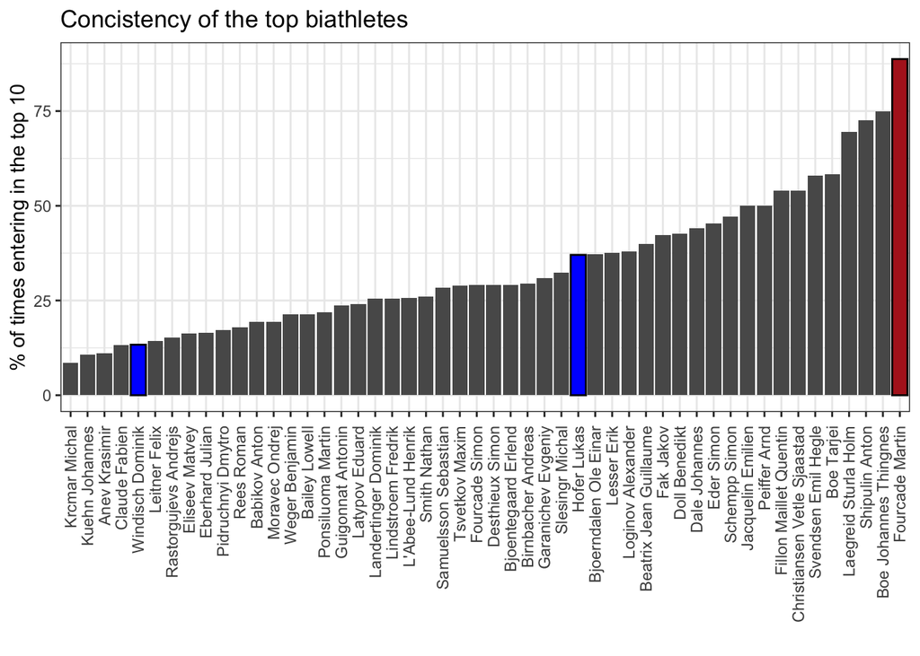

```r
plot <- ggplot() +
        geom_col(aes(x=names(named_percentages) , y=sort(unname(percentages)))) +

        scale_x_discrete(labels = names(named_percentages)[order_perc]) +

        theme_bw() +
        theme(axis.text.x = element_text(angle = 90, hjust=1, vjust=0.5)) +
        geom_col(aes(x=31 , y=unname(named_percentages[names(named_percentages)=='Hofer Lukas ']))
                 , fill='blue', color='black') +
        geom_col(aes(x=5 , y=unname(named_percentages[names(named_percentages)=='Windisch Dominik ']))
                 , fill='blue', color='black') +
        geom_col(aes(x=50 , y=unname(named_percentages[names(named_percentages)=='Fourcade Martin ']))
                 , fill='firebrick', color='black') +
        labs(x = '', y = '% of times entering in the top 10', title = 'Concistency of the top biathletes')
plot
```

We see with no surprise how the most consistent biathlete is Martin Fourcade (highlighted in red), not anyone gets the name Monsieur Le Biathlon after all. It comes with quite the surprise though the massive advantage he has with respect to another great as Johannes Thingnes Bø, a whopping 88.7% against 75%. We have to consider though that our data starts from the 2014/2015 season so when Fourcade was already in its prime while Johannes was moving his big but first steps in the word cup. In blue we can see the two Italians represented, as we know Luki is by far the most consistent but the infamous echoes of a certain word championship still rings in our ears… CINQUE!

p.s. that Oestersund mass start isn’t represented in this part of the analysis as Dominik entered the last shooting range outside the top 10… we all know the ending though.

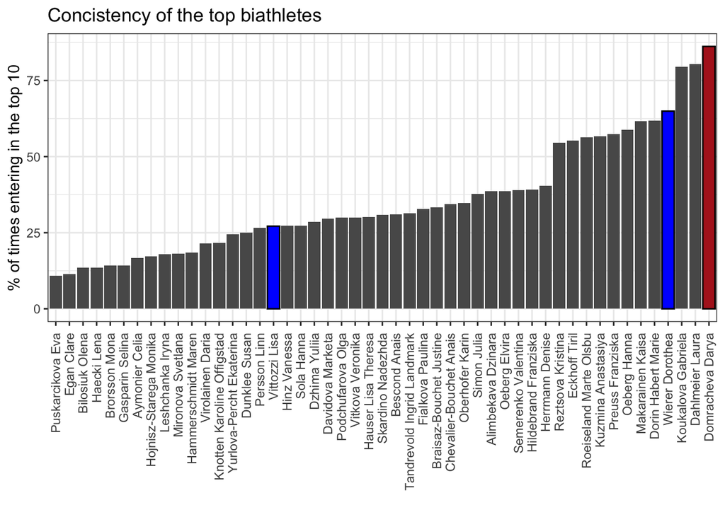

```r
plot <- ggplot() +
        geom_col(aes(x=names(named_percentages_w) , y=sort(unname(percentages_w)))) +

        scale_x_discrete(labels = names(named_percentages_w)[order_perc_w]) +

        theme_bw() +
        theme(axis.text.x = element_text(angle = 90, hjust=+1, vjust = 0.5)) +
        geom_col(aes(x=46 , y=unname(named_percentages_w[names(named_percentages_w)=='Wierer Dorothea ']))
                 , fill='blue', color='black') +
        geom_col(aes(x=17 , y=unname(named_percentages_w[names(named_percentages_w)=='Vittozzi Lisa ']))
                 , fill='blue', color='black') +
        geom_col(aes(x=49 , y=unname(named_percentages_w[names(named_percentages_w)=='Domracheva Darya ']))
                 , fill='firebrick', color='black') +
        labs(x = '', y = '% of times entering in the top 10', title = 'Concistency of the top biathletes')
plot
```

In the women’s case Domracheva, Dahlmeier and Koukalova are in a class of their own, we can notice how there isn’t a big drop in the percentage of times entering the last range in the top 10 from Domracheva to Dahlmeier contrary to what happened in the men’s case. Speaking of our heroines, Dorothea is top notch while Lisa struggle a little bit more, we have to consider though that the Sappada native was moving her first steps in the word cup at the beginning of the data acquisition.

```r
# The data frame that will contain data representing the efficiency
efficiency_df <- data.frame(table(top_names_bottom$full_name), table(top_names_top_10$full_name))
efficiency_df_w <- data.frame(table(top_names_bottom_w$full_name), table(top_names_top_10_w$full_name))
# Eliminating the duplicate of the names
efficiency_df$Var1.1 <- NULL
efficiency_df_w$Var1.1 <- NULL
# Re-defining the column names
colnames(efficiency_df) <- c('Full Names', '# Out top 10', '# In top 10')
colnames(efficiency_df_w) <- c('Full Names', '# Out top 10', '# In top 10')
head(efficiency_df)
```

```
##                Full Names # Out top 10 # In top 10
## 1          Anev Krasimir            40           5
## 2          Babikov Anton            25           6
## 3          Bailey Lowell            33           9
## 4 Beatrix Jean Guillaume            21          14
## 5     Birnbacher Andreas            12           5
## 6    Bjoentegaard Erlend            34          14
```

```r
head(efficiency_df_w)
```

```
##                 Full Names # Out top 10 # In top 10
## 1      Alimbekava Dzinara            19          12
## 2          Aymonier Celia            35           7
## 3           Bescond Anais            62          28
## 4          Bilosiuk Olena            32           5
## 5 Braisaz-Bouchet Justine            50          25
## 6           Brorsson Mona            54           9
```

```r
# Getting the misses in the top 10
miss_top_10 <- aggregate(x = top_names_top_10$final_range, by=list(Names = top_names_top_10$full_name),
                         FUN = sum)

miss_top_10_w <- aggregate(x = top_names_top_10_w$final_range, by=list(Names = top_names_top_10_w$full_name),
                         FUN = sum)
head(miss_top_10)
```

```
##                     Names  x
## 1          Anev Krasimir   6
## 2          Babikov Anton   5
## 3          Bailey Lowell  10
## 4 Beatrix Jean Guillaume  12
## 5     Birnbacher Andreas   1
## 6    Bjoentegaard Erlend  17
```

```r
head(miss_top_10_w)
```

```
##                      Names  x
## 1      Alimbekava Dzinara  14
## 2          Aymonier Celia  11
## 3           Bescond Anais  24
## 4          Bilosiuk Olena   2
## 5 Braisaz-Bouchet Justine  32
## 6           Brorsson Mona  16
```

```r
# Misses when approaching not in the top ten
miss_no_top_10 <- aggregate(x = top_names_bottom$final_range, by=list(Names = top_names_bottom$full_name),
                         FUN = sum)
head(miss_no_top_10)
```

```
##                     Names  x
## 1          Anev Krasimir  25
## 2          Babikov Anton  21
## 3          Bailey Lowell  30
## 4 Beatrix Jean Guillaume  24
## 5     Birnbacher Andreas   8
## 6    Bjoentegaard Erlend  34
```

```r
miss_no_top_10_w<- aggregate(x = top_names_bottom_w$final_range, by=list(Names = top_names_bottom_w$full_name),
                         FUN = sum)
head(miss_no_top_10_w)
```

```
##                      Names  x
## 1      Alimbekava Dzinara  18
## 2          Aymonier Celia  58
## 3           Bescond Anais  64
## 4          Bilosiuk Olena  20
## 5 Braisaz-Bouchet Justine  64
## 6           Brorsson Mona  46
```

```r
# Updating the efficiency df with Misses and attempts
efficiency_df <- cbind(efficiency_df, 'Misses top 10' = miss_top_10$x,
      'Attempts top 10' = efficiency_df$`# In top 10`*5,
      'Misses not top 10' = miss_no_top_10$x,
      'Attempts no top 10' = efficiency_df$`# Out top 10`*5)

efficiency_df_w <- cbind(efficiency_df_w, 'Misses top 10' = miss_top_10_w$x,
      'Attempts top 10' = efficiency_df_w$`# In top 10`*5,
      'Misses not top 10' = miss_no_top_10_w$x,
      'Attempts no top 10' = efficiency_df_w$`# Out top 10`*5)
```

```r
head(efficiency_df)
```

```
##                Full Names # Out top 10 # In top 10 Misses top 10
## 1          Anev Krasimir            40           5             6
## 2          Babikov Anton            25           6             5
## 3          Bailey Lowell            33           9            10
## 4 Beatrix Jean Guillaume            21          14            12
## 5     Birnbacher Andreas            12           5             1
## 6    Bjoentegaard Erlend            34          14            17
##   Attempts top 10 Misses not top 10 Attempts no top 10
## 1              25                25                200
## 2              30                21                125
## 3              45                30                165
## 4              70                24                105
## 5              25                 8                 60
## 6              70                34                170
```

```r
head(efficiency_df_w)
```

```
##                 Full Names # Out top 10 # In top 10 Misses top 10
## 1      Alimbekava Dzinara            19          12            14
## 2          Aymonier Celia            35           7            11
## 3           Bescond Anais            62          28            24
## 4          Bilosiuk Olena            32           5             2
## 5 Braisaz-Bouchet Justine            50          25            32
## 6           Brorsson Mona            54           9            16
##   Attempts top 10 Misses not top 10 Attempts no top 10
## 1              60                18                 95
## 2              35                58                175
## 3             140                64                310
## 4              25                20                160
## 5             125                64                250
## 6              45                46                270
```

Now we wanna determine a proper prior, due to its conjugate properties we choose a beta prior. We use a beta having as mean the mean, for each biathlete, of the probability of hitting a shot. We should be careful though, the last shooting range is always a standing shooting range, so we take the hits and misses only for the last two shots.

```r
# Adding the full name to the no_chrono data frame
df_no_chrono_men$full_name <- paste(df_no_chrono_men$Family.Name, df_no_chrono_men$Given.Name, '')

df_no_chrono_women$full_name <- paste(df_no_chrono_women$Family.Name, df_no_chrono_women$Given.Name, '')

# Function to compute the mistakes in the standing shootings
last_shots <- function(x){
  #Making our string an iterable
  iterable <- unlist(strsplit((x),""))
  #Taking the shots of interest
  string_shots <- iterable[c(5, 7)]
  #Converting the first shot
  first_shot <- as.numeric(string_shots[1])
  # Converting the second shot
  second_shot <- as.numeric(string_shots[2])
  # Returning the total mistakes
  return(first_shot + second_shot)
}

# Making the column with the total misses
df_no_chrono_men$miss_last_2 <- sapply(X = df_no_chrono_men$Shootings, FUN = last_shots)
df_no_chrono_women$miss_last_2 <- sapply(X = df_no_chrono_women$Shootings, FUN = last_shots)

# Making the column with the standing precision
df_no_chrono_men$standing_prob <- (10-df_no_chrono_men$miss_last_2)/10
df_no_chrono_women$standing_prob <- (10-df_no_chrono_women$miss_last_2)/10
```

```r
head(df_no_chrono_men)
```

```
##   ID   location Nation Rank Bib Family.Name Given.Name      year race_type
## 1  1 Anterselva    GER    1   1     Schempp      Simon 2014-2015   Pursuit
## 2  1 Anterselva    AUT    2   8        Eder      Simon 2014-2015   Pursuit
## 3  1 Anterselva    RUS    3   2  Garanichev    Evgeniy 2014-2015   Pursuit
## 4  1 Anterselva    NOR    4   9 Bjoerndalen  Ole Einar 2014-2015   Pursuit
## 5  1 Anterselva    FRA    5  25    Fourcade     Martin 2014-2015   Pursuit
## 6  1 Anterselva    GER    6  19      Lesser       Erik 2014-2015   Pursuit
##   Total Shootings Total.Time Behind Isolated.Pursuit Cumulative.Time Loop.Time
## 1     2   1+1+0+0    31:27.9                 31:27.9          1555.9     379.1
## 2     1   0+1+0+0    31:28.0   +0.1          30:52.0          1554.5     380.8
## 3     1   0+0+1+0    31:29.0   +1.1          31:15.0          1553.9     382.4
## 4     0   0+0+0+0    31:29.8   +1.9          30:46.8          1555.5     380.4
## 5     0   0+0+0+0    31:59.8  +31.9          30:39.8          1579.0     378.8
## 6     0   0+0+0+0    32:13.5  +45.6          31:05.5          1584.3     383.3
##   Course.Time Range.Time Shooting.Time Penalty.Time Ski.Time final_range
## 1       329.8       41.1            21          8.2        0           0
## 2       332.5       39.3            20          9.0        0           0
## 3       334.2       38.9            21          9.3        0           0
## 4       332.0       39.7            22          8.7        0           0
## 5       329.7       40.3            21          8.8        0           0
## 6       329.4       46.0            26          7.9        0           0
##                full_name miss_last_2 standing_prob
## 1         Schempp Simon            0           1.0
## 2            Eder Simon            0           1.0
## 3    Garanichev Evgeniy            1           0.9
## 4 Bjoerndalen Ole Einar            0           1.0
## 5       Fourcade Martin            0           1.0
## 6           Lesser Erik            0           1.0
```

```r
head(df_no_chrono_women)
```

```
##   ID   location Nation Rank Bib  Family.Name Given.Name      year race_type
## 1  1 Anterselva    BLR    1   1   Domracheva      Darya 2014-2015   Pursuit
## 2  1 Anterselva    RUS    2  11   Virolainen      Daria 2014-2015   Pursuit
## 3  1 Anterselva    FIN    3   2   Makarainen      Kaisa 2014-2015   Pursuit
## 4  1 Anterselva    GER    4   6   Hildebrand  Franziska 2014-2015   Pursuit
## 5  1 Anterselva    FRA    5  19 Dorin Habert      Marie 2014-2015   Pursuit
## 6  1 Anterselva    USA    6   8      Dunklee      Susan 2014-2015   Pursuit
##   Total Shootings Total.Time  Behind Isolated.Pursuit Cumulative.Time Loop.Time
## 1     1   1+0+0+0    30:58.5                  30:58.5          1517.7     367.4
## 2     1   0+0+0+1    32:19.5 +1:21.0          31:05.5          1601.3     400.9
## 3     5   2+0+1+2    32:27.5 +1:29.0          32:00.5          1629.4     414.7
## 4     1   0+0+1+0    32:27.8 +1:29.3          31:26.8          1613.8     385.0
## 5     2   0+1+1+0    32:36.5 +1:38.0          31:10.5          1629.7     379.1
## 6     1   0+1+0+0    32:39.3 +1:40.8          31:29.3          1630.9     385.7
##   Course.Time Range.Time Shooting.Time Penalty.Time Ski.Time final_range
## 1       311.4       46.0            26         10.0        0           0
## 2       319.7       49.5            28         31.7        0           1
## 3       310.1       52.0            31         52.6        0           2
## 4       321.3       54.5            34          9.2        0           0
## 5       316.3       53.7            31          9.1        0           0
## 6       322.8       54.3            32          8.6        0           0
##               full_name miss_last_2 standing_prob
## 1     Domracheva Darya            0           1.0
## 2     Virolainen Daria            1           0.9
## 3     Makarainen Kaisa            3           0.7
## 4 Hildebrand Franziska            1           0.9
## 5   Dorin Habert Marie            1           0.9
## 6        Dunklee Susan            0           1.0
```

```r
# Total misses for each biathlete over the full data frame
misses <- aggregate(x = df_no_chrono_men$miss_last_2, by = list(Names = df_no_chrono_men$full_name),
                    FUN = sum)$x

# Data frame with the number of occurrences
occ <- as.data.frame(table(df_no_chrono_men$full_name))

# Creating the joint data frame
hit_miss <- cbind(occ, misses)

# Each occurences corresponds to 10 shots
hit_miss$Freq <- hit_miss$Freq*10

# Renaming the shots
colnames(hit_miss) <- c('Names', 'Tot_Attempts', 'Misses')

# Inserting the total attempts
hit_miss$Hits <- hit_miss$Tot_Attempts - hit_miss$Misses

# Inserting the mean probability for each biathlete
hit_miss$Probabilities <- hit_miss$Hits/hit_miss$Tot_Attempts

# Restricting to the atlethes inside the top_names vector
top_names_hit_miss <- hit_miss[hit_miss$Names %in% top_names,]

head(top_names_hit_miss)
```

```
##                      Names Tot_Attempts Misses Hits Probabilities
## 4           Anev Krasimir           450     61  389     0.8644444
## 8           Babikov Anton           310     54  256     0.8258065
## 9           Bailey Lowell           420     86  334     0.7952381
## 13 Beatrix Jean Guillaume           350     76  274     0.7828571
## 17     Birnbacher Andreas           170     19  151     0.8882353
## 19    Bjoentegaard Erlend           480    112  368     0.7666667
```

```r
# Total misses for each biathlete over the full data frame
misses_w <- aggregate(x = df_no_chrono_women$miss_last_2, by = list(Names = df_no_chrono_women$full_name),
                    FUN = sum)$x

# Data frame with the number of occurrences
occ_w <- as.data.frame(table(df_no_chrono_women$full_name))

# Creating the joint data frame
hit_miss_w <- cbind(occ_w, misses_w)

# Each occurences corresponds to 10 shots
hit_miss_w$Freq <- hit_miss_w$Freq*10

# Renaming the shots
colnames(hit_miss_w) <- c('Names', 'Tot_Attempts', 'Misses')

# Inserting the total attempts
hit_miss_w$Hits <- hit_miss_w$Tot_Attempts - hit_miss_w$Misses

# Inserting the mean probability for each biathlete
hit_miss_w$Probabilities <- hit_miss_w$Hits/hit_miss_w$Tot_Attempts

# Restricting to the atlethes inside the top_names vector
top_names_hit_miss_w <- hit_miss_w[hit_miss_w$Names %in% top_names_w,]

head(top_names_hit_miss_w)
```

```
##                       Names Tot_Attempts Misses Hits Probabilities
## 4       Alimbekava Dzinara           310     57  253     0.8161290
## 7           Aymonier Celia           420    124  296     0.7047619
## 16           Bescond Anais           900    167  733     0.8144444
## 18          Bilosiuk Olena           370     53  317     0.8567568
## 25 Braisaz-Bouchet Justine           750    174  576     0.7680000
## 26           Brorsson Mona           630    127  503     0.7984127
```

```r
# Computing the standard deviation of the probabilities
std <- aggregate(x = df_no_chrono_men$standing_prob,
          by = list(Category = df_no_chrono_men$full_name), FUN = sd)

# Restricting to top_names
top_names_std <- std[std$Category %in% top_names,]

# Updating the top_names_hit_miss data frame
top_names_hit_miss$std <- top_names_std$x

head(top_names_hit_miss)
```

```
##                      Names Tot_Attempts Misses Hits Probabilities       std
## 4           Anev Krasimir           450     61  389     0.8644444 0.1227628
## 8           Babikov Anton           310     54  256     0.8258065 0.1210172
## 9           Bailey Lowell           420     86  334     0.7952381 0.1464247
## 13 Beatrix Jean Guillaume           350     76  274     0.7828571 0.1543215
## 17     Birnbacher Andreas           170     19  151     0.8882353 0.1166316
## 19    Bjoentegaard Erlend           480    112  368     0.7666667 0.1342169
```

```r
# Computing the standard deviation of the probabilities
std_w <- aggregate(x = df_no_chrono_women$standing_prob,
          by = list(Category = df_no_chrono_women$full_name), FUN = sd)

# Restricting to top_names
top_names_std_w <- std_w[std_w$Category %in% top_names_w,]

# Updating the top_names_hit_miss data frame
top_names_hit_miss_w$std <- top_names_std_w$x

head(top_names_hit_miss_w)
```

```
##                       Names Tot_Attempts Misses Hits Probabilities        std
## 4       Alimbekava Dzinara           310     57  253     0.8161290 0.14164927
## 7           Aymonier Celia           420    124  296     0.7047619 0.13243016
## 16           Bescond Anais           900    167  733     0.8144444 0.13784954
## 18          Bilosiuk Olena           370     53  317     0.8567568 0.09291735
## 25 Braisaz-Bouchet Justine           750    174  576     0.7680000 0.14534209
## 26           Brorsson Mona           630    127  503     0.7984127 0.14311293
```

```r
# The function to compute the alpha of the beta given mean and variance
alpha <- function(mode, sigma){
  return(mean^2*( (1-mean)/(sigma^2) - 1/mean ))
}

# The function to compute the beta of the beta given mean and alpha
beta <- function(alpha, mode){
  return(
    ((alpha - 1) - (alpha - 2)*mode)/mode
  )
}

root_func <- function(m, v){
  uni_func <- function(x){
    return(v*x^3 + x^2*(m^3-m^2 + 7*m*v - 3*v) + x*(-2*m^3 + 16*(m^2)*v + m^2 -
                                             14*m*v + 3*v) + (12*(m^3)*v -16*(m^2)*v +
                                                                7*m*v - v))
  }
  return(uniroot(uni_func, lower=1, upper=50)$root)

}
```

```r
top_names_hit_miss$alpha <- unlist(map2(.x= top_names_hit_miss$Probabilities,
                                        .y=top_names_hit_miss$std^2, .f=root_func))

top_names_hit_miss$beta <- beta(alpha = top_names_hit_miss$alpha,
                                  mode = top_names_hit_miss$Probabilities)


top_names_hit_miss_w$alpha <- unlist(map2(.x= top_names_hit_miss_w$Probabilities,
                                        .y=top_names_hit_miss_w$std^2, .f=root_func))

top_names_hit_miss_w$beta <- beta(alpha = top_names_hit_miss_w$alpha,
                                  mode = top_names_hit_miss_w$Probabilities)
```

```r
head(top_names_hit_miss)
```

```
##                      Names Tot_Attempts Misses Hits Probabilities       std
## 4           Anev Krasimir           450     61  389     0.8644444 0.1227628
## 8           Babikov Anton           310     54  256     0.8258065 0.1210172
## 9           Bailey Lowell           420     86  334     0.7952381 0.1464247
## 13 Beatrix Jean Guillaume           350     76  274     0.7828571 0.1543215
## 17     Birnbacher Andreas           170     19  151     0.8882353 0.1166316
## 19    Bjoentegaard Erlend           480    112  368     0.7666667 0.1342169
##       alpha     beta
## 4  7.880571 2.078958
## 8  8.583431 2.599630
## 9  6.022175 2.293135
## 13 5.433172 2.229639
## 17 8.294905 1.917902
## 19 7.373320 2.939706
```

```r
head(top_names_hit_miss_w)
```

```
##                       Names Tot_Attempts Misses Hits Probabilities        std
## 4       Alimbekava Dzinara           310     57  253     0.8161290 0.14164927
## 7           Aymonier Celia           420    124  296     0.7047619 0.13243016
## 16           Bescond Anais           900    167  733     0.8144444 0.13784954
## 18          Bilosiuk Olena           370     53  317     0.8567568 0.09291735
## 25 Braisaz-Bouchet Justine           750    174  576     0.7680000 0.14534209
## 26           Brorsson Mona           630    127  503     0.7984127 0.14311293
##        alpha     beta
## 4   6.336627 2.202323
## 7   7.777404 3.839183
## 16  6.706881 2.300204
## 18 13.474729 3.085680
## 25  6.225416 2.578511
## 26  6.300295 2.338245
```

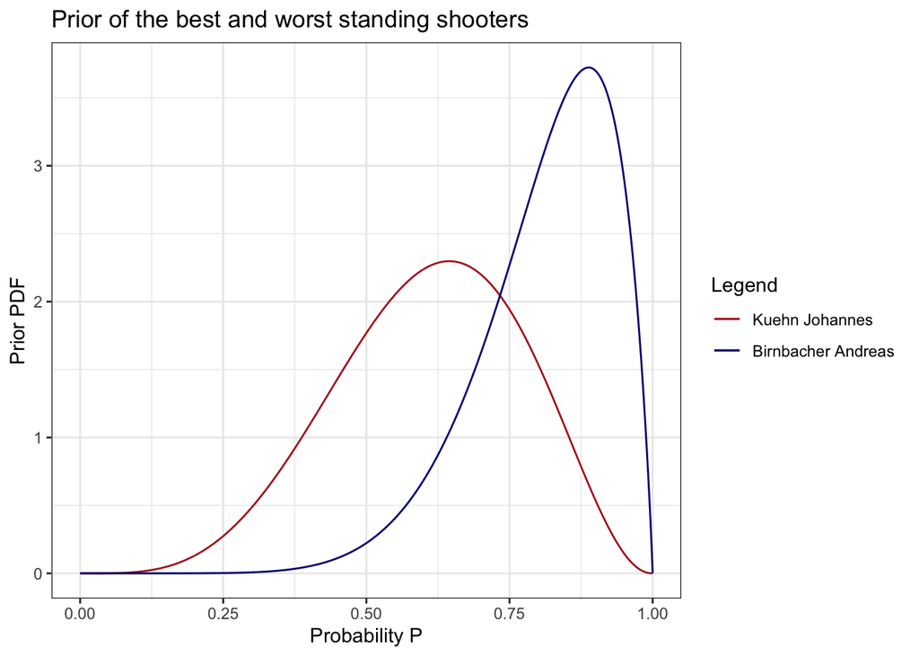

```r
x_axis <- seq(0, 1, 0.001)
min_idx <- which.min(top_names_hit_miss$Probabilities)
min_prob <- top_names_hit_miss[min_idx,]

max_idx <- which.max(top_names_hit_miss$Probabilities)
max_prob <- top_names_hit_miss[max_idx,]

plot <- ggplot() +
        geom_line(aes(x=x_axis, y=dbeta(x=x_axis, shape1 = min_prob$alpha, shape2 = min_prob$beta),
                                        color = as.character(min_prob$Names))) +
        geom_line(aes(x=x_axis, y=dbeta(x=x_axis, shape1 = max_prob$alpha, shape2 = max_prob$beta),
                                        color = as.character(max_prob$Names))) +
        labs(color = 'Legend', x='Probability P', y='Prior PDF', title=
               'Prior of the best and worst standing shooters') +
        scale_color_manual(values= c("Kuehn Johannes " = 'firebrick', "Birnbacher Andreas " = 'navy')) +
        theme_bw()
plot
```

We see how the prior probability of a sharp-shoother like Birnbacher is peaked far to the right with respect to a very good skier but someone who’s standing shooting is a liability like Johannes Kuehn.

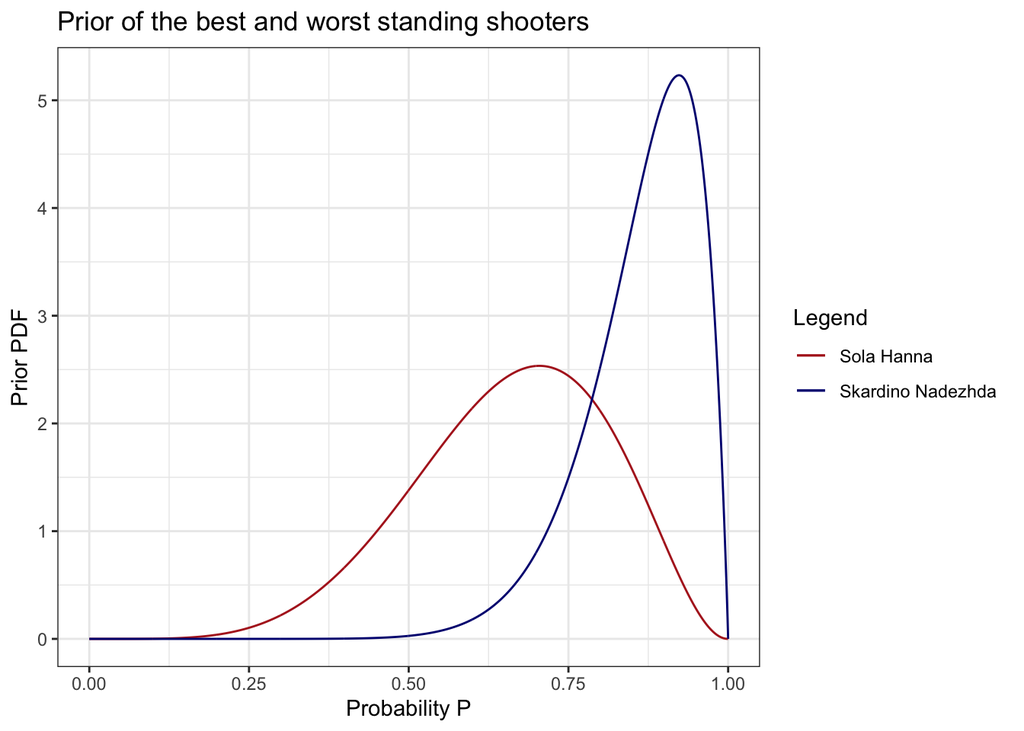

```r
x_axis <- seq(0, 1, 0.001)
min_idx_w <- which.min(top_names_hit_miss_w$Probabilities)
min_prob_w <- top_names_hit_miss_w[min_idx_w,]

max_idx_w <- which.max(top_names_hit_miss_w$Probabilities)
max_prob_w <- top_names_hit_miss_w[max_idx_w,]

plot <- ggplot() +
        geom_line(aes(x=x_axis, y=dbeta(x=x_axis, shape1 = min_prob_w$alpha, shape2 = min_prob_w$beta),
                                        color = as.character(min_prob_w$Names))) +
        geom_line(aes(x=x_axis, y=dbeta(x=x_axis, shape1 = max_prob_w$alpha, shape2 = max_prob_w$beta),
                                        color = as.character(max_prob_w$Names))) +
        labs(color = 'Legend', x='Probability P', y='Prior PDF', title=
               'Prior of the best and worst standing shooters') +
        scale_color_manual(values= c("Sola Hanna " = 'firebrick', "Skardino Nadezhda " = 'navy')) +
        theme_bw()
plot
```

Also here we notice how the a strong skier but inconsistent shooter like Hanna Sola has the prior peaked at the worst percentage while in this battle within the Belarus’ borders Skardino performs much better.

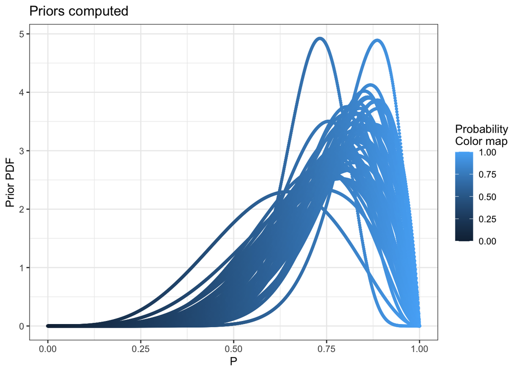

```r
plot <- ggplot() +
        geom_point(aes(x=rep(x_axis, nrow(top_names_hit_miss)),
                       y=dbeta(x=rep(x_axis, nrow(top_names_hit_miss)),
                        shape1 = top_names_hit_miss$alpha, shape2 = top_names_hit_miss$beta
                        ),color=rep(x_axis, nrow(top_names_hit_miss))), size=0.8) +

        labs(color = 'Probability \nColor map', x='P', y='Prior PDF', title=
               'Priors computed') +

        theme_bw()
plot
```

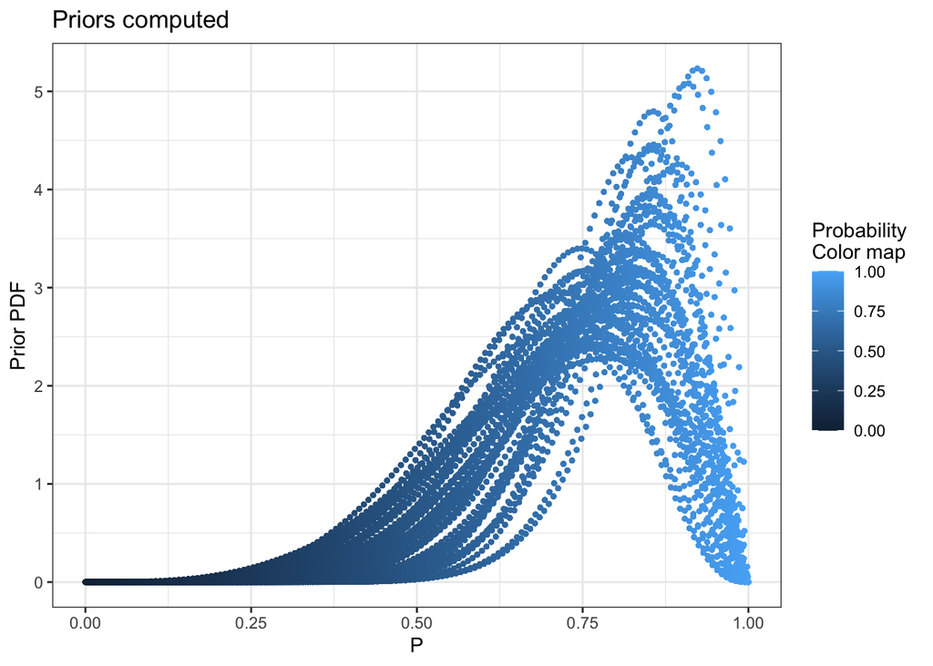

```r
plot <- ggplot() +
        geom_point(aes(x=rep(x_axis, nrow(top_names_hit_miss_w)),
                       y=dbeta(x=rep(x_axis, nrow(top_names_hit_miss_w)),
                        shape1 = top_names_hit_miss_w$alpha, shape2 = top_names_hit_miss_w$beta
                        ),color=rep(x_axis, nrow(top_names_hit_miss_w))), size=0.8) +

        labs(color = 'Probability \nColor map', x='P', y='Prior PDF', title=
               'Priors computed') +

        theme_bw()
plot
```

We see how here the transition from low percentages to high ones is much smoother than in the men case

The next step is to insert the paramters of our priors into the efficiency_df

```r
# Hits top 10
efficiency_df$Hits_top_ten <- efficiency_df$`Attempts top 10` - efficiency_df$`Misses top 10`
# Hits when not in the top 10
efficiency_df$Hits_no_top_ten <- efficiency_df$`Attempts no top 10` - efficiency_df$`Misses not top 10`
# Values of the alpha parameter of the beta
efficiency_df$alpha_prior <- top_names_hit_miss$alpha
# Values of the beta parameter of the beta
efficiency_df$beta_prior <- top_names_hit_miss$beta
# alpha of the posterior when in the top 10
efficiency_df$alpha_post_10 <- efficiency_df$alpha_prior + efficiency_df$Hits_top_ten
# beta of the posterior when in the top 10
efficiency_df$beta_post_10 <- efficiency_df$beta_prior +
  efficiency_df$`Attempts top 10` - efficiency_df$Hits_top_ten
# alpha of the posterior when not in the top 10
efficiency_df$alpha_post_no10 <- efficiency_df$alpha_prior + efficiency_df$Hits_no_top_ten
# beta of the posterior when not in the top 10
efficiency_df$beta_post_no10 <- efficiency_df$beta_prior +
  efficiency_df$`Attempts no top 10` - efficiency_df$Hits_no_top_ten

# Hits top 10
efficiency_df_w$Hits_top_ten <- efficiency_df_w$`Attempts top 10` - efficiency_df_w$`Misses top 10`
# Hits when not in the top 10
efficiency_df_w$Hits_no_top_ten <- efficiency_df_w$`Attempts no top 10` - efficiency_df_w$`Misses not top 10`
# Values of the alpha parameter of the beta
efficiency_df_w$alpha_prior <- top_names_hit_miss_w$alpha
# Values of the beta parameter of the beta
efficiency_df_w$beta_prior <- top_names_hit_miss_w$beta
# alpha of the posterior when in the top 10
efficiency_df_w$alpha_post_10 <- efficiency_df_w$alpha_prior + efficiency_df_w$Hits_top_ten
# beta of the posterior when in the top 10
efficiency_df_w$beta_post_10 <- efficiency_df_w$beta_prior +
  efficiency_df_w$`Attempts top 10` - efficiency_df_w$Hits_top_ten
# alpha of the posterior when not in the top 10
efficiency_df_w$alpha_post_no10 <- efficiency_df_w$alpha_prior + efficiency_df_w$Hits_no_top_ten
# beta of the posterior when not in the top 10
efficiency_df_w$beta_post_no10 <- efficiency_df_w$beta_prior +
  efficiency_df_w$`Attempts no top 10` - efficiency_df_w$Hits_no_top_ten


(efficiency_df)
```

```
##                      Full Names # Out top 10 # In top 10 Misses top 10
## 1                Anev Krasimir            40           5             6
## 2                Babikov Anton            25           6             5
## 3                Bailey Lowell            33           9            10
## 4       Beatrix Jean Guillaume            21          14            12
## 5           Birnbacher Andreas            12           5             1
## 6          Bjoentegaard Erlend            34          14            17
## 7        Bjoerndalen Ole Einar            22          13             9
## 8        Boe Johannes Thingnes            22          66            65
## 9                   Boe Tarjei            35          49            50
## 10 Christiansen Vetle Sjaastad            23          27            20
## 11               Claude Fabien            33           5             7
## 12               Dale Johannes            14          11            15
## 13             Desthieux Simon            61          25            25
## 14               Doll Benedikt            54          40            52
```

[output cut: 189 more lines]

```r
efficiency_df_w
```

```
##                     Full Names # Out top 10 # In top 10 Misses top 10
## 1          Alimbekava Dzinara            19          12            14
## 2              Aymonier Celia            35           7            11
## 3               Bescond Anais            62          28            24
## 4              Bilosiuk Olena            32           5             2
## 5     Braisaz-Bouchet Justine            50          25            32
## 6               Brorsson Mona            54           9            16
## 7     Chevalier-Bouchet Anais            40          21            18
## 8             Dahlmeier Laura            10          41            21
## 9            Davidova Marketa            31          13            16
## 10           Domracheva Darya             4          25            23
## 11         Dorin Habert Marie            16          26            24
## 12              Dunklee Susan            45          15            17
## 13              Dzhima Yuliia            45          18            16
## 14              Eckhoff Tiril            34          42            49
```

[output cut: 185 more lines]

```r
# Function to compute the mode of the beta
mode_beta <- function(alpha, beta){
  return( (alpha - 1)/(alpha + beta - 2) )
}
```

```r
efficiency_df$mode_post_no10 <- mode_beta(efficiency_df$alpha_post_no10, efficiency_df$beta_post_no10)
efficiency_df$mode_post_10 <- mode_beta(efficiency_df$alpha_post_10, efficiency_df$beta_post_10)

efficiency_df_w$mode_post_no10 <- mode_beta(efficiency_df_w$alpha_post_no10, efficiency_df_w$beta_post_no10)
efficiency_df_w$mode_post_10 <- mode_beta(efficiency_df_w$alpha_post_10, efficiency_df_w$beta_post_10)
```

```r
efficiency_df$mode_eff <- (efficiency_df$mode_post_no10 - efficiency_df$mode_post_10)/
                          efficiency_df$mode_post_no10
max_eff <- efficiency_df[which.max(efficiency_df$mode_eff),]
min_eff <- efficiency_df[which.min(efficiency_df$mode_eff),]



efficiency_df_w$mode_eff <- (efficiency_df_w$mode_post_no10 - efficiency_df_w$mode_post_10)/
                          efficiency_df_w$mode_post_no10
max_eff_w <- efficiency_df_w[which.max(efficiency_df_w$mode_eff),]
min_eff_w <- efficiency_df_w[which.min(efficiency_df_w$mode_eff),]
```

```r
efficiency_list <- list()
for (athlete in efficiency_df$`Full Names`){
  efficiency_list[[athlete]] <- 100*(rbeta(n = 10000, shape1 =
                                     efficiency_df[efficiency_df$`Full Names`==athlete,]$alpha_post_no10,
                                     shape2 =
                                       efficiency_df[efficiency_df$`Full Names`==athlete,]$beta_post_no10) -
                            rbeta(n = 10000, shape1 =
                                     efficiency_df[efficiency_df$`Full Names`==athlete,]$alpha_post_10,
                                     shape2 =
                                       efficiency_df[efficiency_df$`Full Names`==athlete,]$beta_post_10))/
                            (rbeta(n = 10000, shape1 =
                                     efficiency_df[efficiency_df$`Full Names`==athlete,]$alpha_post_no10,
                                     shape2 =
                                       efficiency_df[efficiency_df$`Full Names`==athlete,]$beta_post_no10))

}



efficiency_list_w <- list()
for (athlete in efficiency_df_w$`Full Names`){
  efficiency_list_w[[athlete]] <- 100*(rbeta(n = 10000, shape1 =
                                     efficiency_df_w[efficiency_df_w$`Full Names`==athlete,]$alpha_post_no10,
                                     shape2 =
                                       efficiency_df_w[efficiency_df_w$`Full Names`==athlete,]$beta_post_no10) -
                            rbeta(n = 10000, shape1 =
                                     efficiency_df_w[efficiency_df_w$`Full Names`==athlete,]$alpha_post_10,
                                     shape2 =
                                       efficiency_df_w[efficiency_df_w$`Full Names`==athlete,]$beta_post_10))/
                            (rbeta(n = 10000, shape1 =
                                     efficiency_df_w[efficiency_df_w$`Full Names`==athlete,]$alpha_post_no10,
                                     shape2 =
                                       efficiency_df_w[efficiency_df_w$`Full Names`==athlete,]$beta_post_no10))

}
```

```r
bins_fd <- function(vec) {
  diff(range(vec)) / (2 * IQR(vec) / length(vec)^(1/3))
}
```

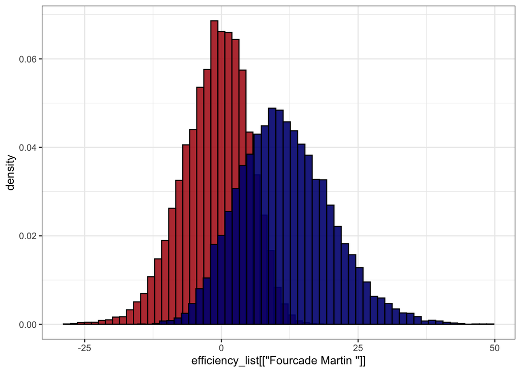

```r
plot <- ggplot() +
        geom_histogram(aes(efficiency_list[['Fourcade Martin ']], y=..density..),
                       fill='firebrick', alpha=0.9, color='black',
                       bins = bins_fd(efficiency_list[['Fourcade Martin ']])) +
        geom_histogram(aes(efficiency_list[['Anev Krasimir ']], y=..density..),
                       fill='navy', alpha=0.9, color='black',
                       bins=bins_fd(efficiency_list[['Anev Krasimir ']])) +
        theme_bw()
plot
```

Here we can see how Martin Fourcade (red histogram), who appeared the most percentually in the top 10, has a perfect 0 “efficiency”. A sympton that he was a cold blooded shooter in the clutch. Krasimir (blue histogram) instead maybe lacking a little bit of experience sow his percentages drop considerably… maybe being in thick of things made his rifle tremble with a 10% “efficiency”.

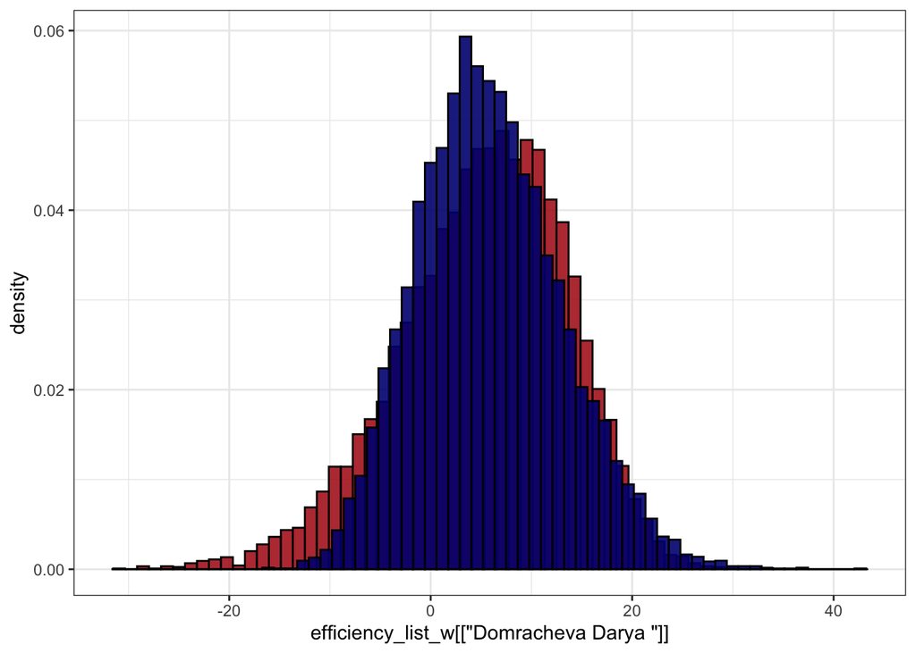

```r
plot <- ggplot() +
        geom_histogram(aes(efficiency_list_w[['Domracheva Darya ']], y=..density..),
                       fill='firebrick', alpha=0.9, color='black',
                       bins = bins_fd(efficiency_list_w[['Domracheva Darya ']])) +
        geom_histogram(aes(efficiency_list_w[['Puskarcikova Eva ']], y=..density..),
                       fill='navy', alpha=0.9, color='black',
                       bins=bins_fd(efficiency_list_w[['Puskarcikova Eva ']])) +
        theme_bw()
plot
```

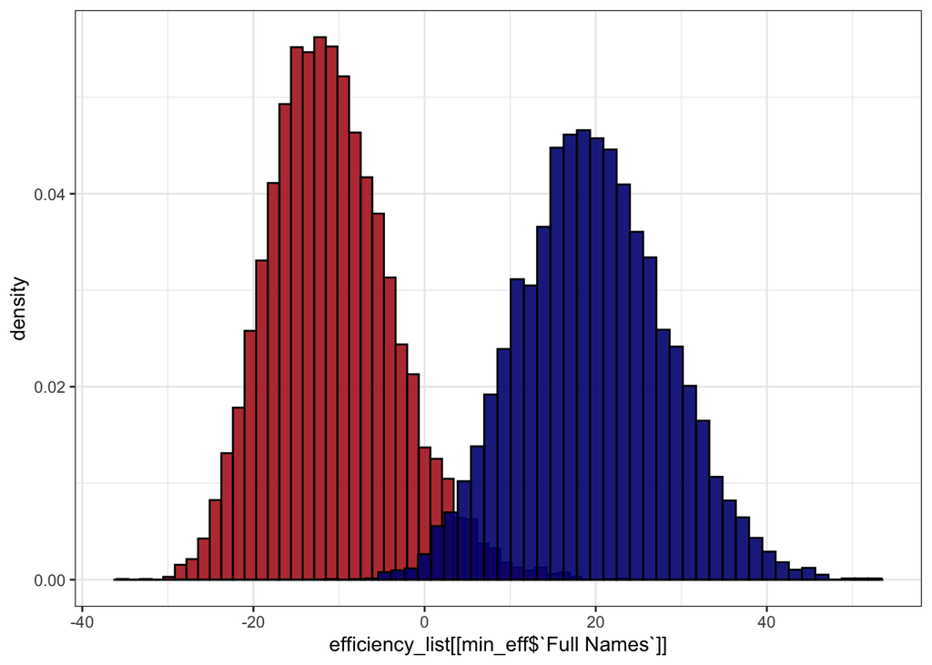

```r
plot <- ggplot() +
        geom_histogram(aes(efficiency_list[[min_eff$`Full Names`]], y=..density..),
                       fill='firebrick', alpha=0.9, color='black',
                       bins = bins_fd(efficiency_list[[min_eff$`Full Names`]])) +
        geom_histogram(aes(efficiency_list[[max_eff$`Full Names`]], y=..density..),
                       fill='navy', alpha=0.9, color='black',
                       bins=bins_fd(efficiency_list[[max_eff$`Full Names`]])) +
        theme_bw()
plot
```

In the above plot we see how Felix Leitner (red histogram) even improved his accuracy in meaningful shootings while Domink Windisch (blue histogram) was the one who suffered the most in this situation (again Oestersund 2019 is not counted). We all know that Dominik is not the most consistent but when we talk about single races in big events he gifted us all great memories.

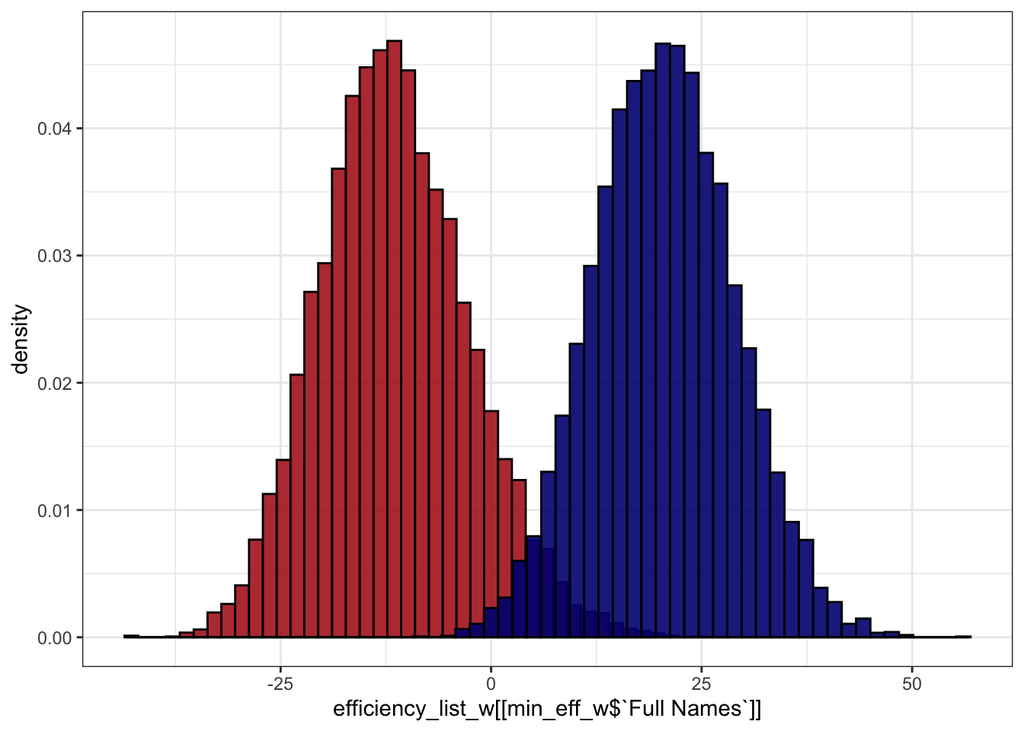

```r
plot <- ggplot() +
        geom_histogram(aes(efficiency_list_w[[min_eff_w$`Full Names`]], y=..density..),
                       fill='firebrick', alpha=0.9, color='black',
                       bins = bins_fd(efficiency_list_w[[min_eff_w$`Full Names`]])) +
        geom_histogram(aes(efficiency_list_w[[max_eff_w$`Full Names`]], y=..density..),
                       fill='navy', alpha=0.9, color='black',
                       bins=bins_fd(efficiency_list_w[[max_eff_w$`Full Names`]])) +
        theme_bw()
plot
```

```r
min_eff_w$`Full Names`
```

```
## [1] Haecki Lena
## 49 Levels: Alimbekava Dzinara  Aymonier Celia  ... Yurlova-Percht Ekaterina
```

```r
max_eff_w$`Full Names`
```

```
## [1] Brorsson Mona
## 49 Levels: Alimbekava Dzinara  Aymonier Celia  ... Yurlova-Percht Ekaterina
```

Laena Hacki here takes the prize of having the coldest blood while Mona Brorsson which is known for her podium-loosing last shots is indeed the biathlete with the highest “efficiency”

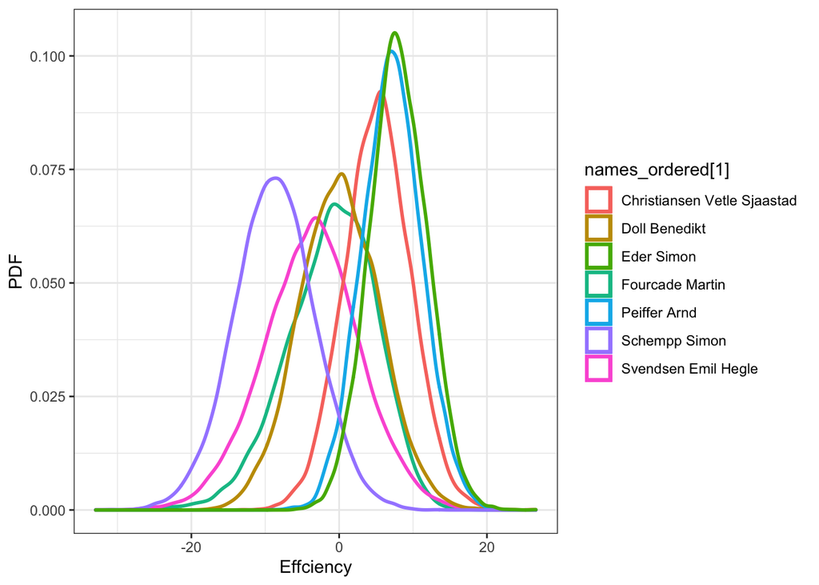

```r
names_ordered <- names(named_percentages[rev(order_perc)])


plot <- ggplot() +
        geom_density(aes(efficiency_list[[names_ordered[1]]], y=..density..,
                           color=names_ordered[1])
                       , alpha=0.5, lwd=1) +
        geom_density(aes(efficiency_list[[names_ordered[6]]], y=..density..,
                          color= names_ordered[6]),
                        alpha=0.5, lwd=1) +
        geom_density(aes(efficiency_list[[names_ordered[7]]], y=..density..,
                           color =  names_ordered[7])
                       , alpha=0.5, lwd=1) +
        geom_density(aes(efficiency_list[[names_ordered[14]]], y=..density..,
                           color= names_ordered[14]),
                        alpha=0.5, lwd=1) +
        geom_density(aes(efficiency_list[[names_ordered[9]]], y=..density..,
                           color= names_ordered[9]),
                        alpha=0.5, lwd=1) +
        geom_density(aes(efficiency_list[[names_ordered[11]]], y=..density..,
                           color= names_ordered[11]),
                        alpha=0.5, lwd=1) +
        geom_density(aes(efficiency_list[[names_ordered[12]]], y=..density..,
                           color= names_ordered[12]),
                        alpha=0.5, lwd=1) +
        labs(x='Effciency', y='PDF') +

        theme_bw()
plot
```

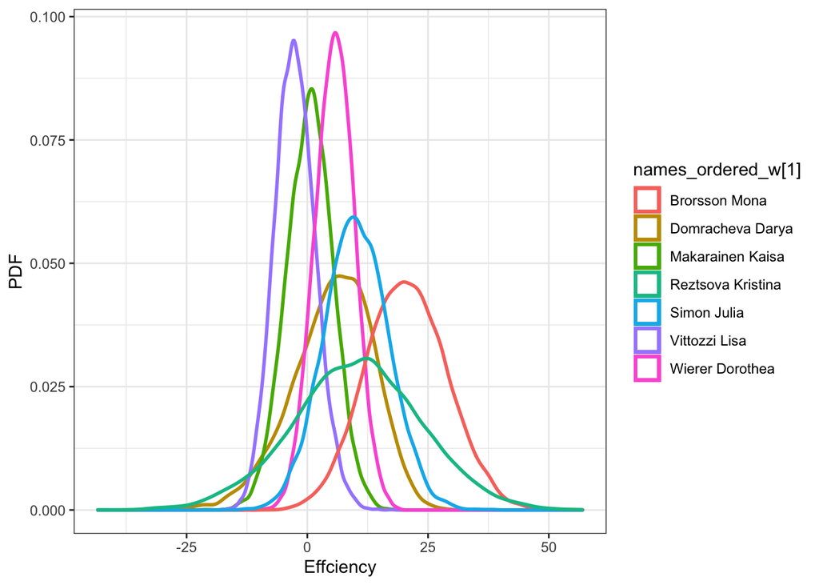

```r
names_ordered_w <- names(named_percentages_w[rev(order_perc_w)])


plot <- ggplot() +
        geom_density(aes(efficiency_list_w[[names_ordered_w[1]]], y=..density..,
                           color=names_ordered_w[1])
                       , alpha=0.5, lwd=1) +
        geom_density(aes(efficiency_list_w[[names_ordered_w[6]]], y=..density..,
                          color= names_ordered_w[6]),
                        alpha=0.5, lwd=1) +
        geom_density(aes(efficiency_list_w[[names_ordered_w[33]]], y=..density..,
                           color =  names_ordered_w[33])
                       , alpha=0.5, lwd=1) +
        geom_density(aes(efficiency_list_w[[names_ordered_w[4]]], y=..density..,
                           color= names_ordered_w[4]),
                        alpha=0.5, lwd=1) +
        geom_density(aes(efficiency_list_w[[names_ordered_w[45]]], y=..density..,
                           color= names_ordered_w[45]),
                        alpha=0.5, lwd=1) +
        geom_density(aes(efficiency_list_w[[names_ordered_w[18]]], y=..density..,
                           color= names_ordered_w[18]),
                        alpha=0.5, lwd=1) +
        geom_density(aes(efficiency_list_w[[names_ordered_w[12]]], y=..density..,
                           color= names_ordered_w[12]),
                        alpha=0.5, lwd=1) +
        labs(x='Effciency', y='PDF') +

        theme_bw()
plot
```

In this set of highly represented athletes we see how consistent are the 2 italians with Lisa that improves her performance and with Dorothea that slightly makes it worse (in terms of “efficiency”). We can see how respecting her family traditions Kristina Reztsova has a very high “efficiency” volatility, she performs good on skis but she isn’t quite the cross country skier lend to biathlon like her mother Anfisa was.